# Introduction to R

# 9 Reading data online

Install and activate the packages `TTR` and `fImport`.

```r
library(TTR)
library(fImport)
```

1. Read the (large) file **lest2001.csv** directly from the following internet site into a data frame `x`. The complete URL is http://www.wiwi.uni-muenster.de/05/download/studium/R/ws1112/data/lest2001.csv

The file is the campus file of the German income tax records 2001 (the data are provided by the Research Data Centre of the Federal Statistical Office, they are described in **lest2001.pdf**). Take care to set the options of the `read.csv` or `read.table` command correctly. The data format is as follows:

- All data entries are separated by semi-colons.
- The first row contains the variables names.
- Missing values are denoted by a dot.
- Apart from the last column all data are integer values.
- The decimal sign in the last column is a dot.

```r
#x <- read.table("http://www.wiwi.uni-muenster.de/05/download/studium/R/ws1112/data/lest2001.csv", header = TRUE, na.strings= ".", dec = ".", sep = ";")
lest2001 <- read.table("../../data/lest2001.csv", header = TRUE, na.strings= ".", dec = ".", sep = ";")
head(lest2001)
```

|  | ef0 | ef8 | ef11 | ef12 | ef48 | ab | merker | tabelle | alter_a | alter_b | kinder | region | sde | gde | einkommen | zve | est_tarif | est_fest | c65101 | c65102 | c65121 | c65122 | c65141 | c65142 | c65161 | c65162 | c65221 | c65222 | c65241 | … |
| --- | --- | --- | --- | --- | --- | --- | --- | --- | --- | --- | --- | --- | --- | --- | --- | --- | --- | --- | --- | --- | --- | --- | --- | --- | --- | --- | --- | --- | --- | --- |
| 1 | 1 | 0 | 2 | 2 | 4 | 1 | 1 | 2 | 4 | 4 | 1 | 1 | 58258 | 58258 | 45239 | 45239 | 8044 | 7532 | NA | NA | NA | NA | NA | NA | 1 | 1 | NA | NA | 1 | … |
| 2 | 2 | 1 | NA | 2 | 1 | 1 | 1 | 1 | 0 | 5 | 0 | 2 | 17536 | 17536 | 15479 | 15479 | 1985 | 1985 | NA | NA | NA | NA | NA | NA | NA | 1 | NA | NA | NA | … |
| 3 | 3 | 0 | 2 | NA | 3 | 1 | 1 | 2 | 4 | 4 | 1 | 1 | 29024 | 29024 | 23573 | 23573 | 2087 | 2087 | NA | NA | NA | NA | NA | NA | 1 | NA | NA | NA | NA | … |
| 4 | 4 | 0 | 6 | NA | 0 | 1 | 1 | 1 | 5 | 0 | 0 | 1 | 10162 | 10162 | 5398 | 5398 | 0 | 0 | NA | NA | 1 | NA | NA | NA | NA | NA | NA | NA | NA | … |
| 5 | 5 | 0 | 2 | NA | 1 | 1 | 1 | 1 | 3 | 0 | 0 | 1 | 68216 | 68216 | 66009 | 66009 | 22143 | 22143 | NA | NA | NA | NA | NA | NA | 1 | NA | NA | NA | NA | … |
| 6 | 6 | 0 | 2 | 2 | 4 | 1 | 1 | 2 | 3 | 3 | 1 | 2 | 54512 | 54512 | 44106 | 44106 | 7691 | 7180 | NA | NA | NA | NA | NA | NA | 1 | 1 | NA | NA | 1 | … |

```r
y <- lest2001$zve
range(y, na.rm = TRUE)
```

```
[1]  -509791 44887210
```

```r
median(y, na.rm = TRUE)
```

```
[1] 22457
```

```r
var(y, na.rm = TRUE)
```

```
[1] 296245129137
```

```r
quantile(y, p = c(0.01, 0.99), na.rm = TRUE)
```

```
        1%        99%
  -5247.16 1282557.64
```

2. Read the help text of the `getYahooData` command of the `TTR` package. Read the data about the Deutsche Bank (symbol *DB*) from January 1st, 2000 to the most recent date into the object `x`. Plot the closing price by `plot(x\$Close)`.

```r
library(TTR)
DB <- getYahooData("DB", start = 20000101)
```

```
TTR::getYahooData is deprecated and will be removed in a future release.
Please use quantmod::getSymbols instead.
```

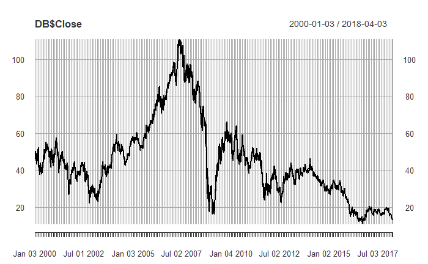

```r
plot(DB$Close)
```

# 10 Indexing vectors

Define the following vectors
$$\begin{align*}
x=\left(
\begin{array}{c}
1 \\
1.1 \\
9 \\
8 \\
1 \\
4 \\
4 \\
1
\end{array}
\right) ,\quad y=\left(
\begin{array}{c}
1 \\
2 \\
3 \\
4 \\
4 \\
3 \\
2 \\
NA
\end{array}
\right) ,\quad z=\left(
\begin{array}{c}
TRUE \\
TRUE \\
FALSE \\
FALSE \\
TRUE \\
FALSE \\
FALSE \\
FALSE
\end{array}
\right)
\end{align*}$$

```r
x <- c(1, 1.1, 9, 8, 1, 4, 4, 1)
y <- c(1, 2, 3, 4, 4, 3, 2, NA)
z <- c(TRUE, TRUE, FALSE, FALSE, TRUE, FALSE, FALSE, FALSE)
```

1. Predict what the following commands will return (and then check if you are right):

```r
x[-2]
```

```
[1] 1 9 8 1 4 4 1
```

```r
x[2:5]
```

```
[1] 1.1 9.0 8.0 1.0
```

```r
x[c(1,5,8)]
```

```
[1] 1 1 1
```

```r
x[-c(1,5,8)]
```

```
[1] 1.1 9.0 8.0 4.0 4.0
```

```r
x[y]
```

```
[1] 1.0 1.1 9.0 8.0 8.0 9.0 1.1  NA
```

```r
x[seq(2,8,by=2)]
```

```
[1] 1.1 8.0 4.0 1.0
```

```r
x[rep(1:3,4)]
```

```
 [1] 1.0 1.1 9.0 1.0 1.1 9.0 1.0 1.1 9.0 1.0 1.1 9.0
```

2. Predict what the following commands will return (and then check if you are right):

```r
y[z]
```

```
[1] 1 2 4
```

```r
y[!z]
```

```
[1]  3  4  3  2 NA
```

```r
y[x>2]
```

```
[1] 3 4 3 2
```

```r
y[x==1]
```

```
[1]  1  4 NA
```

```r
x[!is.na(y)]
```

```
[1] 1.0 1.1 9.0 8.0 1.0 4.0 4.0
```

```r
y[!is.na(y)]
```

```
[1] 1 2 3 4 4 3 2
```

3. Indexing is not only used to read certain elements of a vector but also to change them. Execute `x2 <- x` to make a copy of `x`. Change all elements of `x2` that have the value 4 to the value $-4$. Print `x2`.

```r
x2 <- x
x2[x2 == 4] <- -4
print(x2)
```

```
[1]  1.0  1.1  9.0  8.0  1.0 -4.0 -4.0  1.0
```

4. Change all elements of `x2` that have the value 1 to a missing value (`NA`). Print `x2`.

```r
x2[x2 == 1] <- NA
print(x2)
```

```
[1]   NA  1.1  9.0  8.0   NA -4.0 -4.0   NA
```

5. Execute `x2[z] <- 0`. Print `x2`.

```r
x2[z] <- 0
print(x2)
```

```
[1]  0  0  9  8  0 -4 -4 NA
```

# 11 Indexing matrices

Define the matrix `x <- matrix(c(1:12,12:1),4,6)`.

```r
x <- matrix(c(1:12, 12:1), 4, 6)
```

1. Predict what the following commands will return (and then check if you are right):

```r
x[1,3]
```

```
[1] 9
```

```r
x[,5]
```

```
[1] 8 7 6 5
```

```r
x[2,]
```

```
[1]  2  6 10 11  7  3
```

```r
x[,-3]
```

```
     [,1] [,2] [,3] [,4] [,5]
[1,]    1    5   12    8    4
[2,]    2    6   11    7    3
[3,]    3    7   10    6    2
[4,]    4    8    9    5    1
```

```r
x[-4,]
```

```
     [,1] [,2] [,3] [,4] [,5] [,6]
[1,]    1    5    9   12    8    4
[2,]    2    6   10   11    7    3
[3,]    3    7   11   10    6    2
```

```r
x[2:3,3:4]
```

```
     [,1] [,2]
[1,]   10   11
[2,]   11   10
```

```r
x[2:4,4]
```

```
[1] 11 10  9
```

2. Predict what the following commands will return (and then check if you are right):

```r
x[x>5]
```

```
 [1]  6  7  8  9 10 11 12 12 11 10  9  8  7  6
```

```r
x[,x[1,]<=5]
```

```
     [,1] [,2] [,3]
[1,]    1    5    4
[2,]    2    6    3
[3,]    3    7    2
[4,]    4    8    1
```

```r
x[x[,2]>6,]
```

```
     [,1] [,2] [,3] [,4] [,5] [,6]
[1,]    3    7   11   10    6    2
[2,]    4    8   12    9    5    1
```

```r
x[x[,2]>6,4:6]
```

```
     [,1] [,2] [,3]
[1,]   10    6    2
[2,]    9    5    1
```

```r
x[x[,1]<3 & x[,2]<6,]
```

```
[1]  1  5  9 12  8  4
```

3. Print all rows where column 5 is at least three times larger than column 6.

```r
x[x[, 5]>= (3 * x[, 6]) , ]
```

```
     [,1] [,2] [,3] [,4] [,5] [,6]
[1,]    3    7   11   10    6    2
[2,]    4    8   12    9    5    1
```

4. Count the number of elements of `x` that are larger than 7.

```r
length(x[x > 7])  # or: sum(x>7)
```

```
[1] 10
```

5. Count the number of elements in row 2 that are smaller than their neighbors in row 1.

```r
sum(x[2, ] < x[1, ])
```

```
[1] 3
```

6. Count the number of elements of `x` that are larger than their left neighbor.

```r
sum(x[, 2:6] > x[, 1:5])  # alternativ: sum(x[,-1]>x[,-6])
```

```
[1] 10
```

# 12 Indexing dataframes

Load the data set **bsp2.txt** as data frame `bsp2` and print it.

```r
bsp2 <- read.csv("../../data/bsp2.txt",as.is=TRUE)
print(bsp2)
```

| X | Y | Z | U | V |
| --- | --- | --- | --- | --- |
| 2.411 | 2.317 | 5.209 | B | M |
| 2.469 | 2.116 | 2.566 | D | M |
| 1.066 | 5.471 | 4.856 | D | M |
| 2.264 | 2.107 | 2.647 | C | M |
| 2.775 | 3.136 | 3.221 | C | M |
| 2.542 | 3.072 | 2.999 | A | M |
| 2.200 | 3.272 | 3.174 | D | F |
| 8.947 | 3.058 | 3.178 | B | M |
| 5.784 | 2.092 | 3.364 | B | F |
| 2.180 | 2.745 | 3.731 | B | M |

[output cut: 30 more lines]

1. Use different ways to print the second column of the data frame `bsp2` (as a vector or a data frame).

```r
bsp2[, 2]
bsp2$Y
bsp2[[2]]
bsp2["Y"]
```

2. Use different ways to print columns $U$ and $V$.

```r
bsp2[, 4]
bsp2$U
bsp2[[4]]
bsp2["U"]
bsp2[, 5]
bsp2$V
bsp2[[5]]
bsp2["V"]
```

3. Use the `attach` command to make the variables directly accessible. Print `X`. Now `detach` the data frame again.

```r
attach(bsp2)
print(X)  # For safety reasons apply rm(list = ls()) upfront
detach(bsp2)
```

4. Print all rows of `bsp2` where the variable $U$ has value A or B.

```r
bsp2[bsp2$U == "A" | bsp2$U == "B", ]
```

|  | X | Y | Z | U | V |
| --- | --- | --- | --- | --- | --- |
| 1 | 2.411 | 2.317 | 5.209 | B | M |
| 6 | 2.542 | 3.072 | 2.999 | A | M |
| 8 | 8.947 | 3.058 | 3.178 | B | M |
| 9 | 5.784 | 2.092 | 3.364 | B | F |
| 10 | 2.180 | 2.745 | 3.731 | B | M |
| 11 | 1.580 | 2.008 | 4.463 | B | M |
| 14 | 2.509 | 6.982 | 1.265 | B | M |
| 18 | 1.724 | 1.857 | 4.980 | B | M |
| 20 | 2.133 | 3.958 | 3.530 | A | M |
| 21 | 5.512 | 1.658 | 3.292 | B | M |

[output cut: 10 more lines]

5. Print all rows of `bsp2` where the variable $X$ is smaller than its median and the variable $Y$ is larger than its median.

```r
bsp2[bsp2$X < median(bsp2$X) & bsp2$Y > median(bsp2$Y), ]
```

|  | X | Y | Z | U | V |
| --- | --- | --- | --- | --- | --- |
| 3 | 1.066 | 5.471 | 4.856 | D | M |
| 7 | 2.200 | 3.272 | 3.174 | D | F |
| 10 | 2.180 | 2.745 | 3.731 | B | M |
| 15 | 1.436 | 4.650 | 2.002 | C | F |
| 16 | 2.275 | 3.761 | 1.376 | D | F |
| 19 | 1.785 | 4.424 | 5.611 | C | F |
| 20 | 2.133 | 3.958 | 3.530 | A | M |
| 28 | 1.344 | 4.229 | 2.308 | A | F |
| 29 | 1.855 | 4.866 | 3.305 | A | F |
| 30 | 0.886 | 2.795 | 4.485 | A | F |

[output cut: 2 more lines]

6. One can add row names to a data frame. Execute the following command and print the data frame to have a look at the new row names:

```r
row.names(bsp2) <- paste(rep(LETTERS[1:20], each = 2), rep(1:2, 20), sep = "")
print(bsp2)
```

|  | X | Y | Z | U | V |
| --- | --- | --- | --- | --- | --- |
| A1 | 2.411 | 2.317 | 5.209 | B | M |
| A2 | 2.469 | 2.116 | 2.566 | D | M |
| B1 | 1.066 | 5.471 | 4.856 | D | M |
| B2 | 2.264 | 2.107 | 2.647 | C | M |
| C1 | 2.775 | 3.136 | 3.221 | C | M |
| C2 | 2.542 | 3.072 | 2.999 | A | M |
| D1 | 2.200 | 3.272 | 3.174 | D | F |
| D2 | 8.947 | 3.058 | 3.178 | B | M |
| E1 | 5.784 | 2.092 | 3.364 | B | F |
| E2 | 2.180 | 2.745 | 3.731 | B | M |

[output cut: 30 more lines]

7. Use the row name and the variable name to print the value of variable `Z` at observation `T1`.

```r
bsp2["T1", "Z"]
```

```
[1] 2.356
```

8. Print the rows for observations `G1` and `G2`.

```r
bsp2[c("G1", "G2"), ]
```

|  | X | Y | Z | U | V |
| --- | --- | --- | --- | --- | --- |
| G1 | 4.316 | 1.868 | 0.731 | D | M |
| G2 | 2.509 | 6.982 | 1.265 | B | M |

# 13 User-defined functions

1. Define a Cobb-Douglas production function with two inputs vectors,
   $$\begin{align*}
   x &=\left(
   \begin{array}{c}
   L \\
   K
   \end{array}
   \right) \\
   \theta &=\left(
   \begin{array}{c}
   A \\
   \alpha \\
   \beta
   \end{array}
   \right)
   \end{align*}$$
   and scalar output
   $$\begin{align*}
   y=AL^{\alpha }K^{\beta }.
   \end{align*}$$
   Evaluate the function at
   $$\begin{align*}
   x &=\left(
   \begin{array}{c}
   2 \\
   3
   \end{array}
   \right) \\
   \theta &=\left(
   \begin{array}{c}
   1 \\
   0.3 \\
   0.8
   \end{array}
   \right) .
   \end{align*}$$

```r
cobb_douglas <- function(x, theta) {
  y <- theta[1] * x[1]^theta[2] * x[2]^theta[3]
  return(y)
}
cobb_douglas(x = c(2, 3), theta = c(1, 0.3, 0.8))
```

```
[1] 2.964872
```

2. Define a function `lowdecile` with one input vector $\left(x_{1},\ldots ,x_{n}\right)$ of arbitrary length. The function should compute and return the mean of all observations in the lowest decile. Define the vector
   $$\begin{align*}
   x=\left( 0,0,0,0,1,1,1,1,2,2,2,2,\ldots ,9,9,9,9\right)
   \end{align*}$$
   and apply `lowdecile` to $x$.

```r
lowdecile <- function(x) {
  quantil <- x[x <= quantile(x, p = 0.1)]
  return(mean(quantil))
}
lowdecile(x = rep(0:9, each = 4))
```

```
[1] 0
```

# 14 Sorting and merging

1. Define $x=\left(-1,0,1,4,9,2,1,4.5,1.1,-0.9\right)$ and sort the vector ascendingly. Print the second smallest element of $x$.

```r
x <- c(-1, 0, 1, 4, 9, 2, 1, 4.5, 1.1, -0.9)
sort(x, decreasing = FALSE)
```

```
 [1] -1.0 -0.9  0.0  1.0  1.0  1.1  2.0  4.0  4.5  9.0
```

```r
sort(x, decreasing = FALSE)[2]
```

```
[1] -0.9
```

2. Sort $x$ descendingly and print the third largest element of $x$.

```r
sort(x, decreasing = TRUE)
```

```
 [1]  9.0  4.5  4.0  2.0  1.1  1.0  1.0  0.0 -0.9 -1.0
```

```r
sort(x, decreasing = TRUE)[3]
```

```
[1] 4
```

3. Execute `x <- matrix(c(1:12,12:1),6,4,byrow=T)` to define the matrix $x$. Calculate the order vector $p$ of the last column of $x$. Sort the matrix $x$ by the last column and print the sorted matrix.

```r
x <- matrix(c(1:12, 12:1), 6, 4, byrow = T)
p <- order(x[, 4])
x[p, ]
```

```
     [,1] [,2] [,3] [,4]
[1,]    4    3    2    1
[2,]    1    2    3    4
[3,]    8    7    6    5
[4,]    5    6    7    8
[5,]   12   11   10    9
[6,]    9   10   11   12
```

4. Load the file **bsp2.txt** into the data frame `bsp2`. Sort `bsp2` by the variable `U` and on the next level by the variable `X`.

```r
bsp2 <- read.csv("../../data/bsp2.txt")
bsp2[order(bsp2$U), ]
```

|  | X | Y | Z | U | V |
| --- | --- | --- | --- | --- | --- |
| 6 | 2.542 | 3.072 | 2.999 | A | M |
| 20 | 2.133 | 3.958 | 3.530 | A | M |
| 24 | 2.575 | 2.967 | 5.191 | A | M |
| 25 | 1.951 | 1.996 | 1.916 | A | M |
| 27 | 1.022 | 1.764 | 2.853 | A | M |
| 28 | 1.344 | 4.229 | 2.308 | A | F |
| 29 | 1.855 | 4.866 | 3.305 | A | F |
| 30 | 0.886 | 2.795 | 4.485 | A | F |
| 36 | 2.606 | 3.889 | 2.388 | A | F |
| 40 | 1.624 | 2.650 | 3.247 | A | F |

[output cut: 30 more lines]

```r
bsp2[order(bsp2$U, bsp2$X), ]
```

|  | X | Y | Z | U | V |
| --- | --- | --- | --- | --- | --- |
| 30 | 0.886 | 2.795 | 4.485 | A | F |
| 27 | 1.022 | 1.764 | 2.853 | A | M |
| 28 | 1.344 | 4.229 | 2.308 | A | F |
| 40 | 1.624 | 2.650 | 3.247 | A | F |
| 29 | 1.855 | 4.866 | 3.305 | A | F |
| 25 | 1.951 | 1.996 | 1.916 | A | M |
| 20 | 2.133 | 3.958 | 3.530 | A | M |
| 6 | 2.542 | 3.072 | 2.999 | A | M |
| 24 | 2.575 | 2.967 | 5.191 | A | M |
| 36 | 2.606 | 3.889 | 2.388 | A | F |

[output cut: 30 more lines]

5. Activate the package `foreign` and load the Stata files **wave2000.dta** and **wave2009.dta** into two data frames. Print the variable names of both data frames. Merge the data frames by the variable `pid`. Keep only persons who are present in both years (by setting the option `all=FALSE`). Print the variables names of the merged data frame.

```r
library(foreign)
wave2000 <- read.dta("../../data/wave2000.dta")
wave2009 <- read.dta("../../data/wave2009.dta")
```

```r
names(wave2000)
```

```
[1] "pid"          "gender"       "age"          "marital"      "children"
[6] "netincome"    "satisfaction"
```

```r
names(wave2009)
```

```
[1] "pid"          "gender"       "age"          "marital"      "children"
[6] "netincome"    "satisfaction"
```

```r
ges <- merge(wave2000, wave2009, by = "pid", all = FALSE)
names(ges)
```

```
 [1] "pid"            "gender.x"       "age.x"          "marital.x"
 [5] "children.x"     "netincome.x"    "satisfaction.x" "gender.y"
 [9] "age.y"          "marital.y"      "children.y"     "netincome.y"
[13] "satisfaction.y"
```

6. Calculate the mean life satisfaction in 2000 and 2009.

```r
mean(ges$satisfaction.x)
```

```
[1] 7.170744
```

```r
mean(ges$satisfaction.y)
```

```
[1] 6.75696
```

7. Calculate the mean change in life satisfaction for persons who were single in 2000 and married in 2009.

```r
subsamp <- ges[ges$marital.x == "Single" & ges$marital.y == "Married", ]
mean(subsamp$satisfaction.y - subsamp$satisfaction.x)
```

```
[1] -0.159383
```

# 15 Frequency tables

1. Read the Stata file **wave2009.dta** into a data frame. Tabulate the variables `gender`, `marital` and `children`.

```r
library(foreign)
wave2009 <- read.dta("../../data/wave2009.dta")
head(wave2009)
```

|  | pid | gender | age | marital | children | netincome | satisfaction |
| --- | --- | --- | --- | --- | --- | --- | --- |
| 1 | 602 | Female | 51 | Married | 1 | 49041.06 | 6 |
| 2 | 604 | Male | 19 | Single | 1 | 49041.06 | 7 |
| 3 | 901 | Female | 58 | Single | 0 | 15036.00 | 5 |
| 4 | 1501 | Male | 51 | Single | 0 | 53837.75 | 9 |
| 5 | 1601 | Male | 69 | Married | 0 | 20427.00 | 3 |
| 6 | 1602 | Female | 48 | Married | 0 | 20427.00 | 5 |

```r
table(wave2009$gender)
```

```
  Male Female
  9850  10782
```

```r
table(wave2009$marital)
```

```
  Married    Single   Widowed  Divorced Separated
    12277      4883      1463      1645       364
```

```r
table(wave2009$children)
```

```
    0     1     2     3     4     5     6     8
15033  2921  2044   506    85    30     5     8
```

2. Read the file **bsp2.txt** into a data frame. Compute and plot the frequency tables of the variables $U$ and $V$.

```r
bsp2 <- read.csv("../../data/bsp2.txt")
table(bsp2[, 4])
```

```
 A  B  C  D
10 10 11  9
```

```r
table(bsp2[, 5])
```

```
 F  M
16 24
```

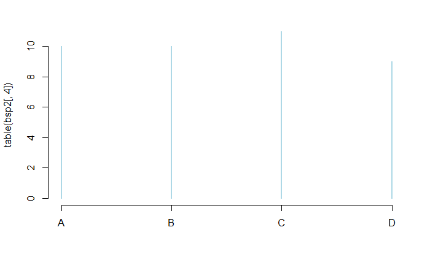

```r
plot(table(bsp2[, 4]), col = "lightblue")
```

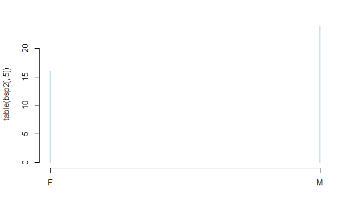

```r
plot(table(bsp2[, 5]), col = "lightblue")
```

3. Define the vector $x=(1,1,1,1,1,2,2,2,2,3,3,3,4,4,5,9)$. Compute the absolute and relative frequency tables and determine the number of different values of $x$.

```r
x <- c(rep(1:5, times = c(5:1)), 9)
abs.freq <- table(x)
print(abs.freq)
```

```
x
1 2 3 4 5 9
5 4 3 2 1 1
```

```r
rel.freq <- abs.freq/length(x)
print(rel.freq)
```

```
x
     1      2      3      4      5      9
0.3125 0.2500 0.1875 0.1250 0.0625 0.0625
```

```r
length(abs.freq)  # or length(unique(x))
```

```
[1] 6
```

4. Read the file **lest2001.csv** (wage and income tax data) into a data frame using the option `as.is=TRUE`. The variable `ef8` gives the gender (male=0, female=1). Tabulate `ef8`.

```r
lest2001 <- read.table("../../data/lest2001.csv", header = TRUE, na.strings = c(".", ""), dec = ".", sep = ";", as.is = T)
class(lest2001$samplingweight)
```

```
[1] "numeric"
```

```r
table(lest2001$ef8)
```

```
     0      1
208563  66179
```

5. The **lest2001.csv** data set contains a weighting variable (`samplingweight`). Each row counts as *samplingweight* observations. Re-compute the absolute frequencies of `ef8` taking into account the weights.

```r
sum(lest2001$samplingweight[lest2001$ef8 == 0])
```

```
[1] 21840881
```

```r
sum(lest2001$samplingweight[lest2001$ef8 == 1])
```

```
[1] 7157623
```

6. Load the Stata file **mikrozensus2002cf.dta** into a data frame (the data are described in the file **mikrozensus2002cf.pdf**). Consider the variable `ef455` (age of flat or house) which is coded into nine classes. Tabulate the age structure.

```r
mikrozensus2002cf <- read.dta("../../data/mikrozensus2002cf.dta")
head(mikrozensus2002cf)
```

|  | ef1 | ef3 | ef4 | ef5 | ef7 | ef9 | ef22 | ef28 | ef30 | ef32 | ef33 | ef35 | ef36 | ef37 | ef38 | ef39 | ef40 | ef41 | ef42 | ef43 | ef44 | ef51 | ef52 | ef53 | ef70 | ef71 | ef72 | ef95 | ef96 | … |
| --- | --- | --- | --- | --- | --- | --- | --- | --- | --- | --- | --- | --- | --- | --- | --- | --- | --- | --- | --- | --- | --- | --- | --- | --- | --- | --- | --- | --- | --- | --- |
| 1 | 1 | 1 | 1 | 1 | 1 | 2 | 1 | 1 | 37 | 1 | 1964 | 2 | 9999 | NA | NA | NA | NA | 1 | 1 | 1 | 1 | NA | 1 | NA | NA | 8 | NA | 1 | NA | … |
| 2 | 1 | 1 | 1 | 2 | 1 | 2 | 1 | 1 | 36 | 2 | 1966 | 2 | 9999 | 1 | 1 | NA | NA | 1 | 1 | 1 | 1 | NA | 1 | NA | NA | 8 | NA | 8 | 8 | … |
| 3 | 1 | 1 | 1 | 3 | 1 | 2 | 1 | 1 | 5 | 2 | 1996 | 1 | NA | 1 | 2 | NA | NA | 1 | 1 | 1 | 1 | NA | 1 | NA | 1 | 8 | NA | NA | NA | … |
| 4 | 1 | 1 | 1 | 4 | 1 | 2 | 1 | 1 | 3 | 2 | 1999 | 1 | NA | 1 | 2 | NA | NA | 1 | 1 | 1 | 1 | NA | 1 | NA | 8 | 8 | NA | NA | NA | … |
| 5 | 1 | 2 | 1 | 1 | 1 | 2 | 1 | 1 | 52 | 1 | 1949 | 2 | 1972 | NA | NA | NA | NA | 8 | NA | 1 | 1 | NA | 1 | NA | NA | 8 | NA | 1 | NA | … |
| 6 | 1 | 2 | 1 | 2 | 1 | 2 | 1 | 1 | 51 | 2 | 1950 | 2 | 1972 | 1 | 1 | NA | NA | 8 | NA | 1 | 1 | NA | 1 | NA | NA | 8 | NA | 1 | NA | … |

```r
table(mikrozensus2002cf$ef455)
```

```
    1     2     3     4     5     6     7     8     9
 2055  1594  2856 11114  3084   945  1271  1746   220
```

# 16 Cumulative distribution function and quantile function

1. Load the data set **bsp1.txt** and calculate the value of the empirical distribution function of `Variable1` at the point $x=10$.

```r
bsp1 <- read.csv2("../../data/bsp1.txt")
ecdf(bsp1$Variable1)(10)
```

```
[1] 0.85
```

2. Plot the empirical distribution function of `Variable2`. Improve the readability of the plot by adding an appropriate heading and axes labels (use the options `main`, `xlab` and `ylab`).

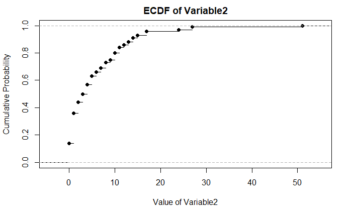

```r
plot(ecdf(bsp1$Variable2), main = "ECDF of Variable2", xlab = "Value of Variable2", ylab = "Cumulative Probability")
```

3. Compute the $p$-quantiles of `Variable1` for $p=0.01,0.05,0.1,0.5,0.9,0.95,0.99$.

```r
quantile(bsp1$Variable1, p = c(0.01, 0.05, 0.1, 0.5, 0.9, 0.95, 0.99))
```

```
   1%    5%   10%   50%   90%   95%   99%
 0.00  0.00  0.00  3.00 12.00 15.00 23.13
```

4. Load the data set **lest2001.csv** and compute the value of the empirical distribution function of `zve` (taxable income) at the points 0, 12000, and 60000.

```r
lest2001 <- read.table("../../data/lest2001.csv", header = TRUE, na.strings = c(".", ""), dec = ".", sep = ";", as.is = T)
# ecdf without weights
ecdf(lest2001$zve[!is.na(lest2001$zve)])(c(0, 12000, 60000))
```

```
[1] 0.04129613 0.29399797 0.87846903
```

5. Use the `quantile` command to compute the 0.99-quantile, the 0.999-quantile, and the 0.9999-quantile of `zve`.

```r
# quantiles without weights
quantile(lest2001$zve, na.rm = TRUE, p = c(0.99, 0.999, 0.9999))
```

```
     99%    99.9%   99.99%
 1282558  5868835 22433760
```

# 17 Mean, variance and standard deviation

1. Read the file **lest2001.csv** (wage and income tax data) into a data frame. The variable `zve` reports taxable income. Compute the mean taxable income without weighting the observations. Then re-compute the mean using the weights given in the `samplingweight`. Hint: Use `weighted.mean`.

```r
lest2001 <- read.table("../../data/lest2001.csv", header = TRUE, na.strings = c(".", ""), dec = ".", sep = ";", as.is = T)
mean(lest2001$zve, na.rm = TRUE)
```

```
[1] 83591.52
```

```r
wm <- weighted.mean(lest2001$zve, w = lest2001$samplingweight, na.rm = TRUE)
print(wm)
```

```
[1] 28867.35
```

2. Compute the unweighted and weighted variance of `zve`.

```r
var(lest2001$zve, na.rm = TRUE)
```

```
[1] 296245129137
```

```r
wvar <- weighted.mean((lest2001$zve - wm)^2, w = lest2001$samplingweight, na.rm = T)
print(wvar)
```

```
[1] 9401914268
```

3. Load the Stata file `mikrozensus2002cf.dta` into a data frame and consider the variables `ef455` (age of flat or house) and `ef466` (cost of heating and warm water in April 2002). Compute the mean cost of heating and warm water for each age class. Hint: You may consider using the command `by`.

```r
mikrozensus2002cf <- read.dta("../../data/mikrozensus2002cf.dta")
mikrozensus2002cf$ef455
```

[output not shown]

[output cut: 25 more lines]

```r
mikrozensus2002cf$ef466
```

[output not shown]

[output cut: 53 more lines]

```r
by(mikrozensus2002cf$ef466, mikrozensus2002cf$ef455, mean, na.rm = TRUE)
```

```
mikrozensus2002cf$ef455: 1
[1] 761.4894
---------------------------------------------------------------
mikrozensus2002cf$ef455: 2
[1] 762.6749
---------------------------------------------------------------
mikrozensus2002cf$ef455: 3
[1] 722.0914
---------------------------------------------------------------
mikrozensus2002cf$ef455: 4
[1] 766.5099
---------------------------------------------------------------
mikrozensus2002cf$ef455: 5
[1] 660.7159
---------------------------------------------------------------
mikrozensus2002cf$ef455: 6
[1] 631.0773
---------------------------------------------------------------
mikrozensus2002cf$ef455: 7
[1] 712.6897
---------------------------------------------------------------
mikrozensus2002cf$ef455: 8
[1] 720.6793
---------------------------------------------------------------
mikrozensus2002cf$ef455: 9
[1] 1476.269
```

# 18 Histograms

In this section, please always use the command `truehist` (which is included in the `MASS` package) to generate histograms.

```r
library(MASS)
```

1. Load the file **gemeinden2006.csv** into a data frame. Delete all observations where the number of inhabitants (`Einwohner`) is smaller than 5. Plot the histogram of the logarithm of the variable `Einwohner.

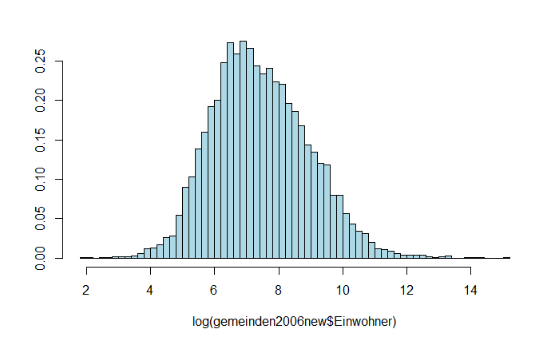

```r
gemeinden2006 <- read.csv2("../../data/gemeinden2006.csv")
gemeinden2006new <- gemeinden2006[gemeinden2006$Einwohner >= 5, ] #or x[!x$Einwohner < 5, ]
truehist(log(gemeinden2006new$Einwohner), col = "lightblue")
```

2.Add the density function of a fitted normal distribution to the histogram.

```r
truehist(log(gemeinden2006new$Einwohner), col = "lightblue")
m <- mean(log(gemeinden2006new$Einwohner))
s <- sd(log(gemeinden2006new$Einwohner))
x <- seq(1, 15, length = 500)
lines(x, dnorm(x, mean = m, sd = s), lwd = 2)
```

3. Load the Stata file **mikrozensus2002cf.dta** into a data frame. Consider the variable `ef462` (rent in April 2002). Drop all observations where the rent exceeds 2000 Euro. Plot the histogram.

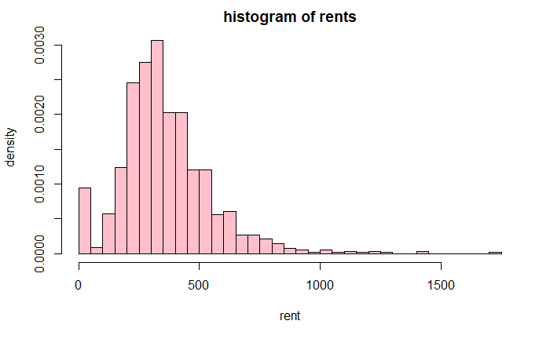

```r
library(foreign)
mikrozensus2002cf <- read.dta("../../data/mikrozensus2002cf.dta")
y <- mikrozensus2002cf$ef462[!is.na(mikrozensus2002cf$ef462)]
yy <- y[y <= 2000]
truehist(yy, col = "pink", xlab = "rent", ylab = "density", main = "histogram of rents")
```

4. Load the Stata file **mikrozensus2002cf.dta** into a data frame.
- Plot the histogram of the variable `ef453` (size of flat in square meters).
- Drop all observations with more than $300$ $m^{2}$ and plot the histogram again.
- Set the number of bins in the histogram to 15.

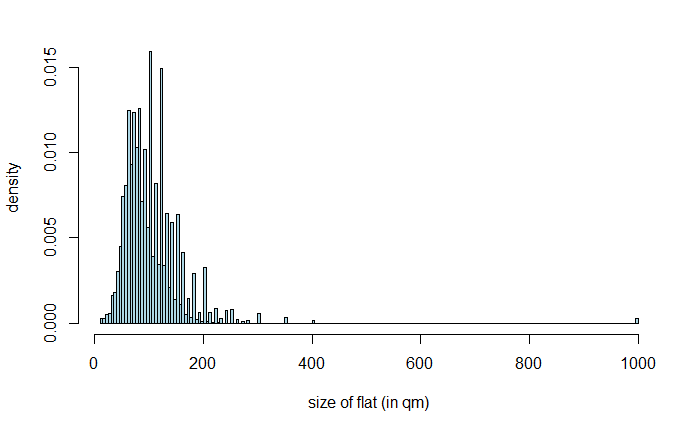

```r
truehist(mikrozensus2002cf$ef453, col = "lightblue", xlab = "size of flat (in qm)", ylab = "density")
```

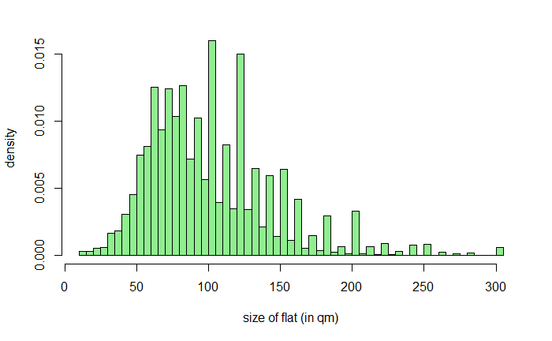

```r
truehist(mikrozensus2002cf$ef453[mikrozensus2002cf$ef453 <= 300], col = "lightgreen", xlab = "size of flat (in qm)", ylab = "density")
```

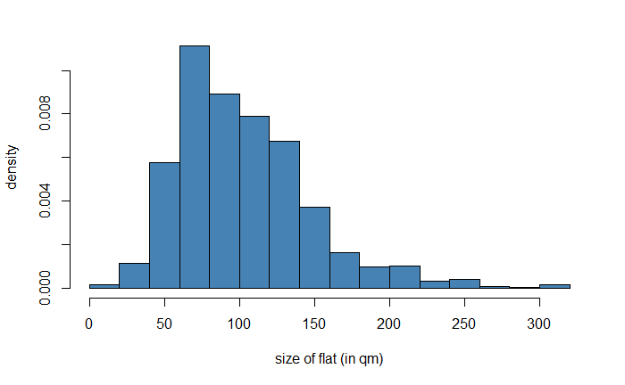

```r
truehist(mikrozensus2002cf$ef453[mikrozensus2002cf$ef453 <= 300], col = "steelblue", nbins = 15, xlab = "size of flat (in qm)", ylab = "density")  # only use 15 classes
```

# 19 Contingency tables, correlation and covariance

1. Execute `data(Titanic)` to load the object `Titanic` of class `table`. Print it as an ordinary table and as a flat table. Plot it as well. Compute the univariate marginal distributions using the `apply` command. Compute the bivariate marginal distribution of survival and social class (again using `apply`).

```r
data(Titanic)
Titanic
```

```
, , Age = Child, Survived = No

      Sex
Class  Male Female
  1st     0      0
  2nd     0      0
  3rd    35     17
  Crew    0      0

, , Age = Adult, Survived = No

      Sex
Class  Male Female
  1st   118      4
  2nd   154     13
  3rd   387     89
  Crew  670      3

, , Age = Child, Survived = Yes

      Sex
Class  Male Female
  1st     5      1
  2nd    11     13
  3rd    13     14
  Crew    0      0

, , Age = Adult, Survived = Yes

      Sex
Class  Male Female
  1st    57    140
  2nd    14     80
  3rd    75     76
  Crew  192     20
```

```r
table(Titanic)
```

```
Titanic
  0   1   3   4   5  11  13  14  17  20  35  57  75  76  80  89 118 140 154 192 387
  8   1   1   1   1   1   3   2   1   1   1   1   1   1   1   1   1   1   1   1   1
670
  1
```

```r
ftable(Titanic)
```

```
                   Survived  No Yes
Class Sex    Age
1st   Male   Child            0   5
             Adult          118  57
      Female Child            0   1
             Adult            4 140
2nd   Male   Child            0  11
             Adult          154  14
      Female Child            0  13
             Adult           13  80
3rd   Male   Child           35  13
             Adult          387  75
      Female Child           17  14
             Adult           89  76
Crew  Male   Child            0   0
             Adult          670 192
      Female Child            0   0
             Adult            3  20
```

```r
ftable(Titanic, row.vars = c("Survived", "Age"))  # Write 'Survived' and 'Age' into rows
```

```
               Class  1st         2nd         3rd        Crew
               Sex   Male Female Male Female Male Female Male Female
Survived Age
No       Child          0      0    0      0   35     17    0      0
         Adult        118      4  154     13  387     89  670      3
Yes      Child          5      1   11     13   13     14    0      0
         Adult         57    140   14     80   75     76  192     20
```

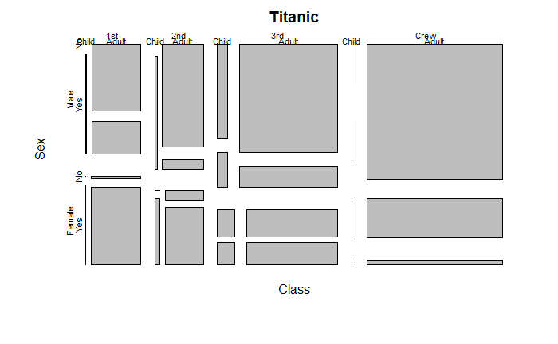

```r
plot(Titanic)
```

```r
apply(Titanic, 1, sum)
```

```
 1st  2nd  3rd Crew
 325  285  706  885
```

```r
apply(Titanic, 2, sum)
```

```
  Male Female
  1731    470
```

```r
apply(Titanic, 3, sum)
```

```
Child Adult
  109  2092
```

```r
apply(Titanic, 4, sum)
```

```
  No  Yes
1490  711
```

```r
apply(Titanic, c(1, 4), sum)
```

```
      Survived
Class   No Yes
  1st  122 203
  2nd  167 118
  3rd  528 178
  Crew 673 212
```

```r
# or margin.table(Titanic,c(1,4))
```

2. Load the file **covmat.csv** into a data frame.

```r
covmat <- read.csv("../../data/covmat.csv")
```

- Compute the covariance matrix using the option `use="complete"`. Check if the covariance matrix is positive definite.

```r
cov(covmat)
```

```
         V1 V2 V3
V1 1.170296 NA NA
V2       NA NA NA
V3       NA NA NA
```

```r
cov(covmat,use="complete")
```

```
            V1          V2         V3
V1  0.35373543 -0.09918577 -0.1629030
V2 -0.09918577  0.34900069  0.4293324
V3 -0.16290303  0.42933237  0.7174221
```

```r
if (sum(eigen(cov(covmat,use="complete"))$value>0) == dim(covmat)[2]){
  print("Matrix is positive definite")
} else {
  print("Matrix is not positive definite")
}
```

```
[1] "Matrix is positive definite"
```

- Now compute the covariance using the option `pairwise` and check again, if the covariance matrix is positive definite.

```r
cov(covmat,use="pairwise")
```

```
           V1         V2        V3
V1  1.1702962 -0.1119788 0.1337978
V2 -0.1119788  0.3051700 0.4293324
V3  0.1337978  0.4293324 0.5038195
```

```r
if (sum(eigen(cov(covmat,use="pairwise"))$value>0) == dim(covmat)[2]){
  print("Matrix is positive definite")
} else {
  print("Matrix is not positive definite")
}
```

```
[1] "Matrix is not positive definite"
```

3. Load the Stata file **mikrozensus2002cf.dta** into a data frame. Consider the two variables `ef141` (normal hours worked) and `ef372` (net income per capita in April 2002). The variable `ef372` is coded into 24 income brackets (see data description **mikrozensus2002cf.pdf**). Drop all observations where `ef372` is larger than 24 (i.e. missing values etc.) and recode the remaining observations to the midpoints of the income brackets. Compute the correlation coefficient of hours worked and net income.

```r
library(foreign)
mikrozensus2002cf <- read.dta("../../data/mikrozensus2002cf.dta")
inc <- mikrozensus2002cf$inc
ef141 <- mikrozensus2002cf$ef141
ef372 <- mikrozensus2002cf$ef372
inc <- ef372[ef372 <= 24]
# We only have the income brackets (1-24) but not the concrete values, hence we build midpoints
# Recode each bracket
inc[inc == "1"] <- 150/2
inc[inc == "2"] <- (150 + 300)/2
inc[inc == "3"] <- (300 + 500)/2
inc[inc == "4"] <- (500 + 700)/2
inc[inc == "5"] <- (700 + 900)/2
inc[inc == "6"] <- (900 + 1100)/2
inc[inc == "7"] <- (1100 + 1300)/2
inc[inc == "8"] <- (1300 + 1500)/2
inc[inc == "9"] <- (1500 + 1700)/2
inc[inc == "10"] <- (1700 + 2000)/2
inc[inc == "11"] <- (2000 + 2300)/2
inc[inc == "12"] <- (2300 + 2600)/2
inc[inc == "13"] <- (2600 + 2900)/2
inc[inc == "14"] <- (2900 + 3200)/2
inc[inc == "15"] <- (3200 + 3600)/2
inc[inc == "16"] <- (3600 + 4000)/2
inc[inc == "17"] <- (4000 + 4500)/2
inc[inc == "18"] <- (4500 + 5000)/2
inc[inc == "19"] <- (5000 + 5500)/2
inc[inc == "20"] <- (5500 + 6000)/2
inc[inc == "21"] <- (6000 + 7500)/2
inc[inc == "22"] <- (7500 + 10000)/2
inc[inc == "23"] <- (10000 + 18000)/2
inc[inc == "24"] <- 18000
# consider only values of ef141 for which ef372<=24, otherwise both vectors would have different sizes
cor(inc, ef141[ef372 <= 24], use = "complete")
```

```
[1] 0.3877711
```

# 20 Programming

1. This exercise illustrates that loops are often not very efficient.
- Create the vector $x=(1,2,\ldots ,1\,000\,000)$ and convert it from *integer* to *numeric* using the conversion command `as.numeric`.

```r
x <- 1:1e+06
class(x)
```

```
[1] "integer"
```

```r
x <- as.numeric(x)
class(x)
```

```
[1] "numeric"
```

- Write a `for`-loop to compute the sum of all vector elements without using the `sum` command. Put the command `p0 <- proc.time()[3]` in front of the loop and the command `print(proc.time()[3]-p0)` at the end. These commands allow to measure the execution time of the loop.

```r
S <- 0  # initialize
p0 <- proc.time()[3]  #Startzeitpunkt festlegen
for (i in x) {
    S <- S + i
}
print(S)
```

```
[1] 500000500000
```

```r
print(proc.time()[3] - p0)  #time used
```

```
elapsed
   0.06
```

*Compare your result with the execution time of the `sum` command.

```r
p0 <- proc.time()[3]
sum(x)
```

```
[1] 500000500000
```

```r
print(proc.time()[3] - p0)
```

```
elapsed
   0.01
```

2. Create a grid vector $x$ of 60 equidistant points $x_{1},,x_{60} $ on the interval $[-10,10]$, and another grid vector $y$ of 70 points $y_{1},\ldots ,y_{70}$ on $[-10,10]$. Create an empty matrix $Z$ of dimension $60\times 70$.

Write a double loop to compute the matrix elements
$$\begin{align*}
Z_{ij}=\frac{10}{r_{ij}}\cdot \sin (r_{ij})
\end{align*}$$

where $r_{ij}=\sqrt{x_{i}^{2}+y_{j}^{2}}$. Execute `persp(x,y,Z)`.

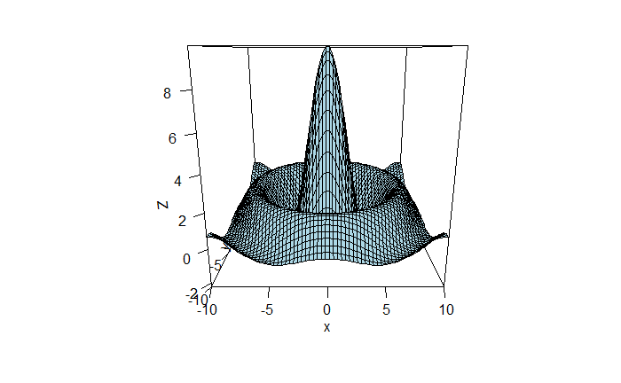

```r
x <- seq(-10, 10, length = 60)
y <- seq(-10, 10, length = 70)
Z <- matrix(NA, 60, 70)
for (i in 1:length(x)) {
    for (j in 1:length(y)) {
        r <- sqrt(x[i]^2 + y[j]^2) # note that r is overwritten in each run of the loop
        Z[i, j] <- 10/r * sin(r)
    }
}
persp(x, y, Z, ticktype = "detailed", col = "lightblue")
```

3. Load the data set **fussballdaten.csv**. It contains all *1. Bundesliga* results between the seasons 1996/1997 and 2008/2009.

```r
fussballdaten <- read.csv2("../../data/fussballdaten.csv", as.is = TRUE)
```

- Create an alphabetically ordered vector of all clubs in the data set.

```r
home <- fussballdaten$Heim
away <- fussballdaten$Auswaerts
clubs <- sort(unique(home))
```

- Write a loop over all clubs. For each club compute the proportion of games won.

```r
ngames <- dim(fussballdaten)[1] # number of games in dataset
GoalsH <- fussballdaten$ToreH
GoalsA <- fussballdaten$ToreA
winner <- rep(NA, ngames)
propwin <- rep(NA, length(clubs))
# Get winning teams
for (i in 1:ngames) {
    if (GoalsH[i] > GoalsA[i]) {
        winner[i] <- home[i]
    }
    if (GoalsA[i] > GoalsH[i]) {
        winner[i] <- away[i]
    }
    if (GoalsH[i] == GoalsA[i]) {
        winner[i] <- "Remis"
    }
}
# Get proportions
for (i in 1:length(clubs)) {
    win <- sum(winner == clubs[i])  # Games won by club i
    tot <- sum(home == clubs[i] | away == clubs[i])  # Number of mathes of club i
    propwin[i] <- win/tot
}
names(propwin) <- clubs
print(propwin)
```

```
1860muenchen       aachen    bielefeld    bmuenchen       bochum       bremen
   0.3496732    0.2647059    0.2720588    0.6153846    0.3202614    0.4751131
     cottbus     dortmund  duesseldorf     duisburg      fckoeln    frankfurt
   0.2823529    0.4298643    0.2500000    0.2598039    0.2689076    0.2830882
    freiburg      hamburg     hannover    herthabsc    karlsruhe     klautern
   0.2720588    0.3891403    0.3235294    0.4144385    0.3308824    0.3823529
  leverkusen        mainz    mgladbach    nuernberg      rostock      schalke
   0.4728507    0.2843137    0.2764706    0.2731092    0.3048128    0.4343891
     stpauli    uerdingen     uhaching          ulm vfbstuttgart    wolfsburg
   0.1960784    0.1470588    0.2941176    0.2647059    0.4185520    0.3582888
```

- Order the clubs descendingly according to the proportion of games won and plot a `barplot` of the proportion.

```r
sort(propwin, decreasing = TRUE)
```

```
   bmuenchen       bremen   leverkusen      schalke     dortmund vfbstuttgart
   0.6153846    0.4751131    0.4728507    0.4343891    0.4298643    0.4185520
   herthabsc      hamburg     klautern    wolfsburg 1860muenchen    karlsruhe
   0.4144385    0.3891403    0.3823529    0.3582888    0.3496732    0.3308824
    hannover       bochum      rostock     uhaching        mainz    frankfurt
   0.3235294    0.3202614    0.3048128    0.2941176    0.2843137    0.2830882
     cottbus    mgladbach    nuernberg    bielefeld     freiburg      fckoeln
   0.2823529    0.2764706    0.2731092    0.2720588    0.2720588    0.2689076
      aachen          ulm     duisburg  duesseldorf      stpauli    uerdingen
   0.2647059    0.2647059    0.2598039    0.2500000    0.1960784    0.1470588
```

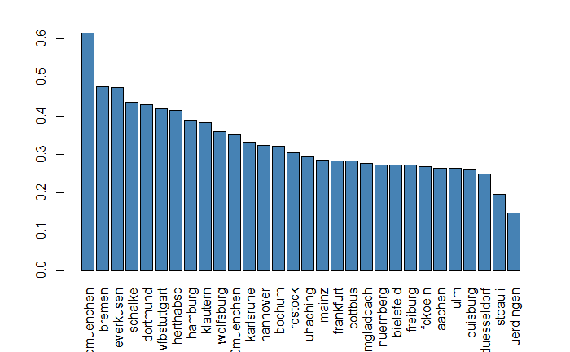

```r
barplot(sort(propwin, decreasing = TRUE), col = "steelblue", las = 3)  # label is printed vertically using las=3
```

4. Load the data set **bsp1.txt**. Use the command `ifelse` to change all zero entries of the first variable to ones (and leave all other entries unchanged).

```r
bsp1 <- read.csv2("../../data/bsp1.txt")
print(bsp1$Variable1)
```

```
  [1] 15  0 11  0  0  2  6 14  0  3  0  1 10  4  1  1  0  3  2  9  7 15  1  0  0  0
 [27]  0 10  3  0  0  5  0 12  7  7 19  1  1  5  1  3 12  7  1  7  3  1  6  1  4 15
 [53] 15  3  2  8  3  2  0  7  5 11  5  5  1  3  2  5  1  2  2  2  3  8  3  0  4 11
 [79]  3  6 11  3  0  2  0 36  1  0  4  8  9 23  0  5  9  4  6  4 12  6
```

```r
bsp1$Variable1 <- ifelse(bsp1$Variable1 == 0, 1, bsp1$Variable1)
print(bsp1$Variable1)
```

```
  [1] 15  1 11  1  1  2  6 14  1  3  1  1 10  4  1  1  1  3  2  9  7 15  1  1  1  1
 [27]  1 10  3  1  1  5  1 12  7  7 19  1  1  5  1  3 12  7  1  7  3  1  6  1  4 15
 [53] 15  3  2  8  3  2  1  7  5 11  5  5  1  3  2  5  1  2  2  2  3  8  3  1  4 11
 [79]  3  6 11  3  1  2  1 36  1  1  4  8  9 23  1  5  9  4  6  4 12  6
```

# 21 Random numbers

This section is not only about random number generation but also includes exercises about the R-functions for standard distributions in statistics.

1. Let’s consider a simple count data example.
- Let $XN( 0,1) $. Compute the probability $P(|X|>3.5)$.

```r
2 * (1 - pnorm(3.5))
```

```
[1] 0.0004652582
```

- Generate $n=10000$ random draws $X_{1},\ldots ,X_{n}$ from $X$ and count the number of observations $|X_{i}|>3.5$.

```r
n <- 10000
X <- rnorm(n)
sum(abs(X) > 3.5)
```

```
[1] 3
```

```r
sum(abs(X) > 3.5)/n
```

```
[1] 3e-04
```

```r
# the larger n the closer it is to the theoretical value of 0.0004652582
```

- Repeat drawing random samples $R=5000$ times and write the counts into a vector $Z_{1},\ldots ,Z_{5000}$ of length 5000.

```r
R <- 5000
Z <- rep(NA, R)
n <- 10000
for (i in 1:R) {
    X <- rnorm(n)
    Z[i] <- sum(abs(X) > 3.5)
}
```

- Tabulate $Z$ and compare the frequencies with the probability function of a suitably fitted Poisson distribution.

```r
table(Z)
```

```
Z
  0   1   2   3   4   5   6   7   8   9  10  11  12  13  14
 49 202 482 865 941 859 661 445 269 114  74  23  13   2   1
```

```r
t(data.frame(observ = 0:16 , prob = dpois(0:16, lambda=mean(Z))*R))
```

```
           [,1]     [,2]     [,3]     [,4]     [,5]     [,6]     [,7]     [,8]
observ  0.00000   1.0000   2.0000   3.0000   4.0000   5.0000   6.0000   7.0000
prob   47.63621 221.6799 515.8047 800.1163 930.8553 866.3656 671.9532 446.7145
           [,9]    [,10]    [,11]    [,12]    [,13]   [,14]     [,15]      [,16]
observ   8.0000   9.0000 10.00000 11.00000 12.00000 13.0000 14.000000 15.0000000
prob   259.8538 134.3617 62.52658 26.45215 10.25815  3.6721  1.220606  0.3786809
            [,17]
observ 16.0000000
prob    0.1101393
```

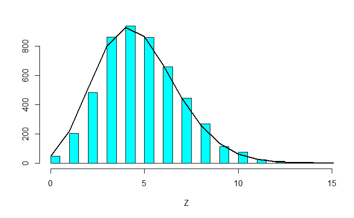

```r
library(MASS)
truehist(Z, prob = F)
x <- seq(0, 16)
lines(x, dpois(x, lambda = mean(Z)) * R, lwd = 2)
```

2. Generate $n=10000$ draws from a log normal distribution $X\sim e^{Y}$ where $Y\sim N(1,0.5^{2})$ (the parameters in the R function are `meanlog=1` and `sdlog=0.5`). Split the screen into two plotting areas using the command `par(mfrow=c(2,1))`. Plot the histograms of $X$ and $\ln X$.

[figure not shown]

```r
n <- 10000
x <- rlnorm(n, meanlog = 1, sdlog = 0.5)
par(mfrow = c(2, 1))
truehist(x)
truehist(log(x))
```

3. Generate $n=10000$ draws from $X\sim N(0,1)$. Compute the cumulated means, i.e.
   $$\begin{align*}
   \bar{X}_{j}=\frac{1}{j}\sum_{i=1}^{j}X_{i}
   \end{align*}$$
   for $j=1,\ldots ,n$ and plot them. Hint: Use the command `cumsum`.

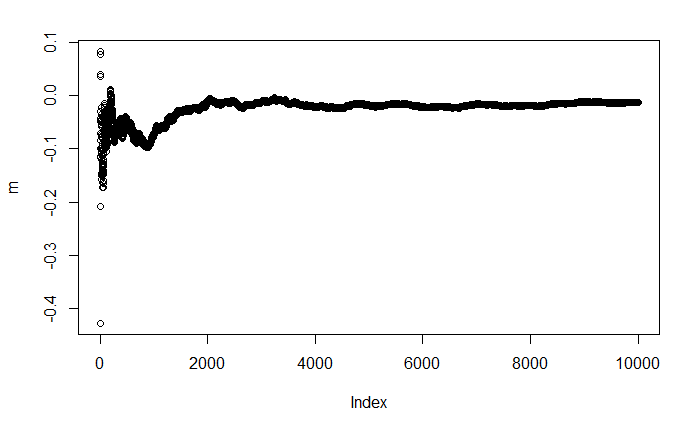

```r
par(mfrow = c(1, 1))
n <- 10000
X <- rnorm(n)
m <- rep(NA, n)
for (i in 1:n) {
    m[i] <- cumsum(X)[i]/i
}
plot(m)
```

# 22 Simulations

1. This exercise illustrates the one-sample $t$-test.
- Generate $n=10$ observations from $X\sim N(10,3^{2})$. Compute the mean and the standard deviation of $X_{1},\ldots ,X_{10}$.

```r
n <- 10
X <- rnorm(n, mean = 10, sd = 3)
m <- mean(X)
s <- sd(X)
print(m)
```

```
[1] 9.537825
```

```r
print(s)
```

```
[1] 2.35083
```

- The $t$-statistics of the hypothesis test $H_{0}:\mu =10$ against $H_{1}:\mu \neq 10$ is
  $$\begin{align*}
  t=\sqrt{10}\frac{\bar{X}-10}{sd}
  \end{align*}$$
  where $sd$ is the standard deviation (as computed by `sd`). Compute the $t$-statistic.

```r
t <- sqrt(n) * (m - 10)/s
print(t)
```

```
[1] -0.621706
```

- Create an empty vector $Z$ of length $R=5000$. Write a loop over $r=1,\ldots ,R$ and repeat the above steps for each $r$. Save the $t$-statistic at $Z_{r}$.

```r
R <- 5000
Z <- rep(NA, R)
for (r in 1:R) {
    X <- rnorm(n, mean = 10, sd = 3)
    m <- mean(X)
    s <- sd(X)
    Z[r] <- sqrt(n) * (m - 10)/s
}
```

- Plot the histogram of $Z_{1},\ldots ,Z_{R}$ and add the density function of the $t_{9}$-distribution.

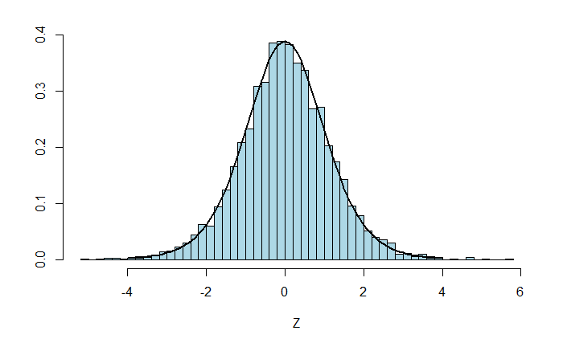

```r
library(MASS)
truehist(Z, col = "lightblue")
x <- seq(-4, 4, by = 0.1)
lines(x, dt(x, df = 9), lwd = 2)
```

2. The classical central limit theorem states that the standardized sum of i.i.d. random variables with finite variance converges in distribution to the standard normal distribution $N(0,1)$. This exercise illustrates the central limit theorem.
- Write a simulation that performs the following steps:
- Generate a random sample $X_{1},\ldots ,X_{5}$ of size $n=5$ from the standard exponential distribution $Exp(1)$.
- Compute the sample sum.
- Repeat the steps $R=10\,000$ times. For each replication, store the sum, e.g. into a vector $Z$.
- Plot the histogram of the sum and add the density function of $N(m,s^{2})$ where $m$ is the mean of $Z$ and $s$ is the standard deviation of $Z$.

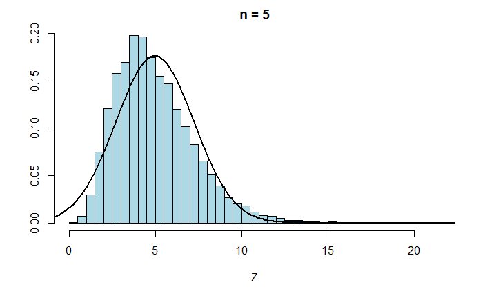

```r
clt_exp <- function(n) {
  R <- 10000
  Z <- rep(NA, R)
  for (r in 1:R) {
      X <- rexp(n, rate = 1)
      Z[r] <- sum(X)
  }
  truehist(Z, col = "lightblue", main=paste("n =",n,sep=" "))
  coord <- par("usr")
  # par("usr") gives you a vector of the form c(x1, x2, y1, y2)
  # giving the extremes of the coordinates of the plotting region
  x <- seq(coord[1], coord[2], by = 0.1)
  lines(x, dnorm(x, mean = mean(Z), sd = sd(Z)), lwd = 2)
}
clt_exp(5)
```

- Increase the sample size $n$ to $n=50,500,5000$ and redo the exercise.

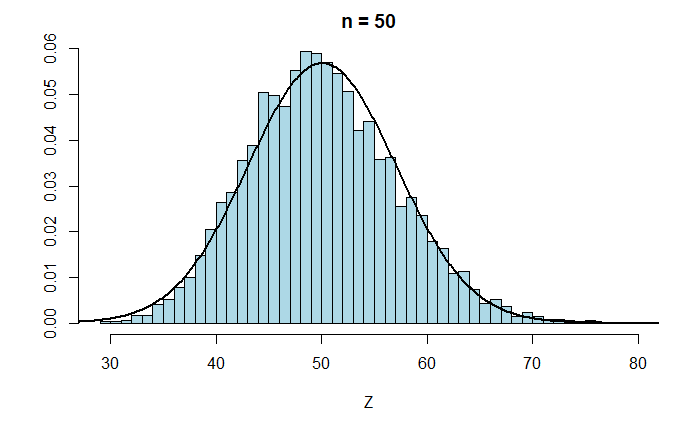

```r
clt_exp(50)
```

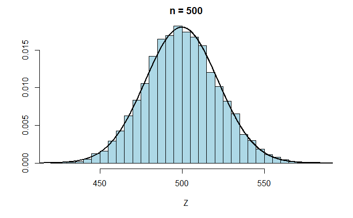

```r
clt_exp(500)
```

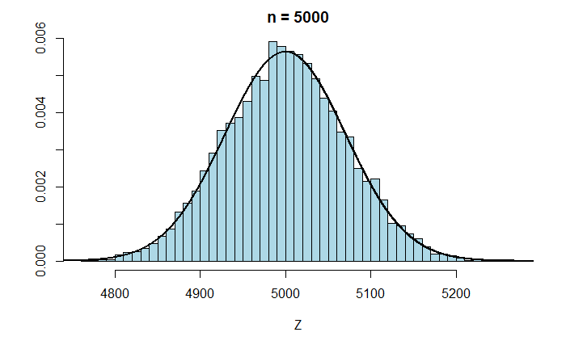

```r
clt_exp(5000)
```

- Redo the exercise with other distributions than the exponential. Use the uniform distribution, the $t$-distribution with 3 degrees of freedom, the Bernoulli distribution (i.e. binomial with parameter size=1), and the Poisson distribution.

```r
clt <- function(n, distrib, df=3, lambda=5, prob=0.6) {
  R <- 10000
  Z <- rep(NA, R)
  for (r in 1:R) {
      if (distrib == 1){
        X <- runif(n)
        strdist <- "Uniform"
        }
      if (distrib == 2){
        X <- rt(n, df = df)
        strdist <- "Student''s t"
        }
      if (distrib == 3){
        X <- rbinom(n, size=1, prob=prob)
        strdist <- "Bernoulli"
        }
      if (distrib == 4){
        X <- rpois(n, lambda = lambda)
        strdist <- "Poisson"
        }
      Z[r] <- sum(X)
  }
  truehist(Z, col = "lightblue", xlab = strdist, main = paste("n =", n, sep = " "))
  coord <- par("usr")
  # par("usr") gives you a vector of the form c(x1, x2, y1, y2)
  # giving the extremes of the coordinates of the plotting region
  x <- seq(coord[1], coord[2], by = 0.1)
  lines(x, dnorm(x, mean = mean(Z), sd = sd(Z)), lwd = 2)
}
```

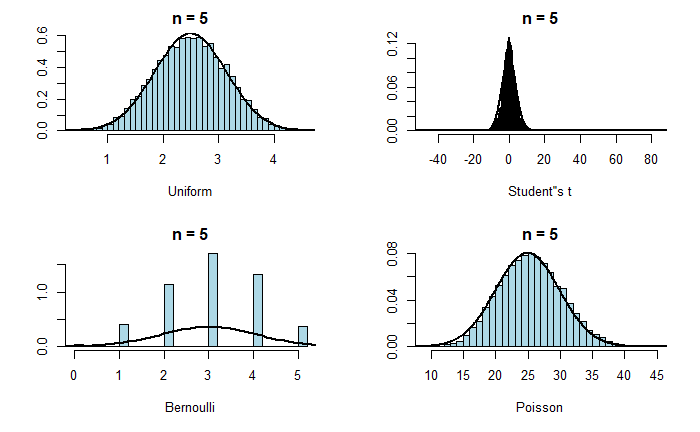

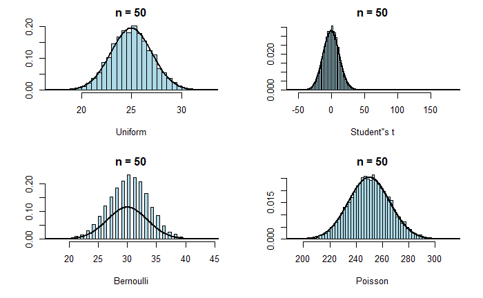

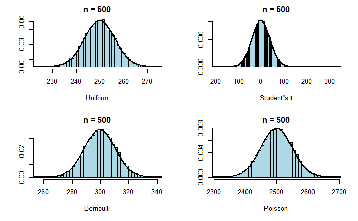

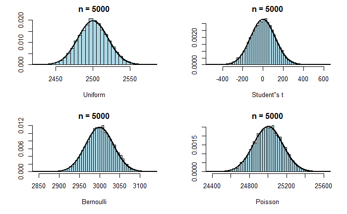

```r
par(mfrow = c(2,2))
for (n in c(5,50,500,5000)) {
  for (i in 1:4) {
    clt(n,i)
  }
}
```

- The central limit theorem breaks down if the variance of the summands is infinite. Redo the exercise using a $t$-distribution with only 1.5 degrees of freedom.

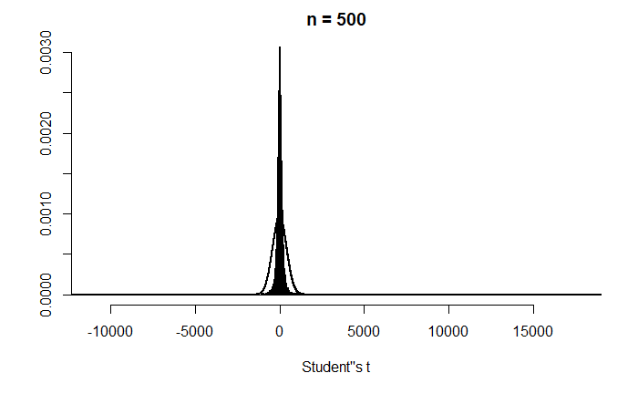

```r
par(mfrow = c(1,1))
clt(500, 2, df = 1.5)
```

# 23 Linear regression

1. Load the Stata data set **wages.dta**. The variables are `earnings` (in Euro, 2009), `age`, `gender` (male=1, female=2), `education` (years of education), `hours` (hours worked during 2009), and `weight`.

```r
library(foreign)
wages <- read.dta("../../data/wages.dta")
```

```r
head(wages)
```

|  | gender | age | education | hours | earnings | weight |
| --- | --- | --- | --- | --- | --- | --- |
| 1 | 2 | 51 | 18 | 1039 | 3900 | 737.73 |
| 2 | 2 | 59 | 18 | 2026 | 55550 | 459.86 |
| 3 | 1 | 22 | 13 | 312 | 2400 | 459.86 |
| 4 | 1 | 37 | 15 | 2338 | 54000 | 459.86 |
| 5 | 2 | 31 | 18 | 2858 | 28800 | 585.21 |
| 6 | 1 | 32 | 15 | 2078 | 9000 | 585.21 |

```r
earnings <- wages$earnings
age <- wages$age
gender <- wages$gender
education <- wages$education
hours <- wages$hours
weight <- wages$weight
```

- Compute the (unweighted) wage equation
  $$\begin{align*}
  \ln \text{earnings}_{i}=\alpha +\beta _{1}\text{age}_{i}+\beta _{2}\text{age}_{i}^{2}+\beta _{3}\text{education}_{i}+\beta _{4}\text{gender}_{i}+u_{i},
  \end{align*}$$
  print the summary of the `lm`-object, and interpret the output.

```r
regr <- lm(log(earnings) ~ age + I(age^2) + education + gender)
summary(regr)
```

```
Call:
lm(formula = log(earnings) ~ age + I(age^2) + education + gender)

Residuals:
    Min      1Q  Median      3Q     Max
-5.4564 -0.3610  0.1617  0.5563  3.6001

Coefficients:
              Estimate Std. Error t value Pr(>|t|)
(Intercept)  5.903e+00  1.163e-01   50.76   <2e-16 ***
age          1.663e-01  5.213e-03   31.91   <2e-16 ***
I(age^2)    -1.726e-03  6.001e-05  -28.76   <2e-16 ***
education    1.067e-01  3.043e-03   35.08   <2e-16 ***
gender      -7.237e-01  1.660e-02  -43.60   <2e-16 ***
---
Signif. codes:  0 ‘***’ 0.001 ‘**’ 0.01 ‘*’ 0.05 ‘.’ 0.1 ‘ ’ 1

Residual standard error: 0.8947 on 11643 degrees of freedom
Multiple R-squared:  0.2888,    Adjusted R-squared:  0.2886
F-statistic:  1182 on 4 and 11643 DF,  p-value: < 2.2e-16
```

- Add an interaction term for `education` and `gender` to the regression.

```r
regr2 <- lm(log(earnings) ~ age + I(age^2) + education + gender + education:gender)
summary(regr2)
```

```
Call:
lm(formula = log(earnings) ~ age + I(age^2) + education + gender +
    education:gender)

Residuals:
    Min      1Q  Median      3Q     Max
-5.4788 -0.3621  0.1572  0.5510  3.5676

Coefficients:
                   Estimate Std. Error t value Pr(>|t|)
(Intercept)       6.610e+00  1.631e-01  40.527  < 2e-16 ***
age               1.659e-01  5.205e-03  31.873  < 2e-16 ***
I(age^2)         -1.717e-03  5.993e-05 -28.649  < 2e-16 ***
education         5.139e-02  9.472e-03   5.426 5.88e-08 ***
gender           -1.204e+00  7.954e-02 -15.134  < 2e-16 ***
education:gender  3.763e-02  6.099e-03   6.170 7.05e-10 ***
---
Signif. codes:  0 ‘***’ 0.001 ‘**’ 0.01 ‘*’ 0.05 ‘.’ 0.1 ‘ ’ 1

Residual standard error: 0.8933 on 11642 degrees of freedom
Multiple R-squared:  0.2911,    Adjusted R-squared:  0.2908
F-statistic: 956.2 on 5 and 11642 DF,  p-value: < 2.2e-16
```

- Compute the weighted hourly wage equation
  $$\begin{align*}
  \ln \frac{\text{earnings}_{i}}{\text{hours}_{i}}=\alpha +\beta _{1}\text{age}_{i}+\beta _{2}\text{age}_{i}^{2}+\beta _{3}\text{education}_{i}+\beta _{4}\text{gender}_{i}+u_{i},
  \end{align*}$$
  print the summary of the `lm`-object, and interpret the output.

```r
regr3 <- lm(log(earnings/hours) ~ age + I(age^2) + education + gender, weights = weight)
summary(regr3)
```

```
Call:
lm(formula = log(earnings/hours) ~ age + I(age^2) + education +
    gender, weights = weight)

Weighted Residuals:
    Min      1Q  Median      3Q     Max
-540.17   -9.18    0.00   14.33  367.44

Coefficients:
              Estimate Std. Error t value Pr(>|t|)
(Intercept)  4.929e-01  9.095e-02   5.419 6.11e-08 ***
age          5.823e-02  4.010e-03  14.524  < 2e-16 ***
I(age^2)    -5.494e-04  4.596e-05 -11.954  < 2e-16 ***
education    8.069e-02  2.368e-03  34.072  < 2e-16 ***
gender      -2.728e-01  1.264e-02 -21.581  < 2e-16 ***
---
Signif. codes:  0 ‘***’ 0.001 ‘**’ 0.01 ‘*’ 0.05 ‘.’ 0.1 ‘ ’ 1

Residual standard error: 36.63 on 10128 degrees of freedom
Multiple R-squared:  0.1757,    Adjusted R-squared:  0.1753
F-statistic: 539.5 on 4 and 10128 DF,  p-value: < 2.2e-16
```

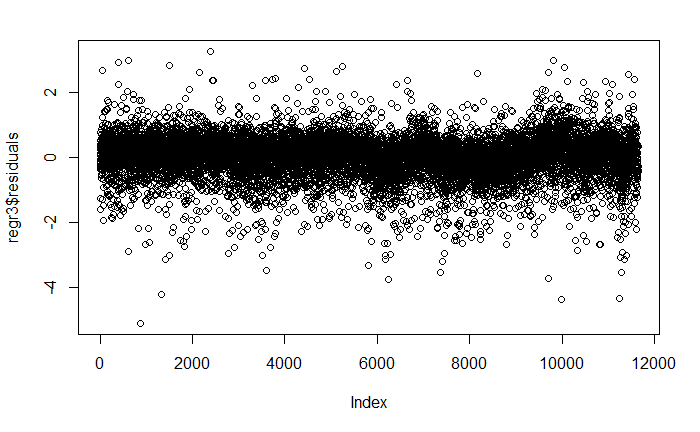

```r
plot(regr3$residuals)
```

- Activate the packages `lmtest` and `sandwich`. Use the function `coeftest` to compute the heteroskedasticity robust standard errors (`vcov=vcovHC`) for the estimated coefficients.

```r
library(lmtest)
library(sandwich)
```

```r
# Robust standard errors
coeftest(regr, vcov = vcovHC)
```

```
t test of coefficients:

               Estimate  Std. Error t value  Pr(>|t|)
(Intercept)  5.9035e+00  1.4065e-01  41.974 < 2.2e-16 ***
age          1.6634e-01  6.3384e-03  26.243 < 2.2e-16 ***
I(age^2)    -1.7256e-03  7.2473e-05 -23.810 < 2.2e-16 ***
education    1.0675e-01  2.9736e-03  35.898 < 2.2e-16 ***
gender      -7.2369e-01  1.6586e-02 -43.633 < 2.2e-16 ***
---
Signif. codes:  0 ‘***’ 0.001 ‘**’ 0.01 ‘*’ 0.05 ‘.’ 0.1 ‘ ’ 1
```

```r
coeftest(regr2, vcov = vcovHC)
```

```
t test of coefficients:

                    Estimate  Std. Error  t value  Pr(>|t|)
(Intercept)       6.6102e+00  1.7589e-01  37.5822 < 2.2e-16 ***
age               1.6591e-01  6.3388e-03  26.1741 < 2.2e-16 ***
I(age^2)         -1.7168e-03  7.2509e-05 -23.6775 < 2.2e-16 ***
education         5.1394e-02  8.8301e-03   5.8203 6.028e-09 ***
gender           -1.2037e+00  7.9682e-02 -15.1059 < 2.2e-16 ***
education:gender  3.7634e-02  6.0272e-03   6.2441 4.410e-10 ***
---
Signif. codes:  0 ‘***’ 0.001 ‘**’ 0.01 ‘*’ 0.05 ‘.’ 0.1 ‘ ’ 1
```

```r
coeftest(regr3, vcov = vcovHC)
```

```
longer object length is not a multiple of shorter object length
```

```
t test of coefficients:

               Estimate  Std. Error  t value  Pr(>|t|)
(Intercept)  4.9288e-01  1.3111e-01   3.7592 0.0001714 ***
age          5.8234e-02  6.1032e-03   9.5417 < 2.2e-16 ***
I(age^2)    -5.4943e-04  7.1504e-05  -7.6838 1.687e-14 ***
education    8.0690e-02  3.4333e-03  23.5025 < 2.2e-16 ***
gender      -2.7276e-01  1.6960e-02 -16.0825 < 2.2e-16 ***
---
Signif. codes:  0 ‘***’ 0.001 ‘**’ 0.01 ‘*’ 0.05 ‘.’ 0.1 ‘ ’ 1
```

- Predict the hourly wage of a male person aged 60 years as a function of education (vary the years of education between 9 and 18). Set the option `se.fit=TRUE`. Inspect the object returned by the `predict` command. Plot the predicted values and add the $\pm 2$ standard deviations confidence intervals.

```r
forecast <- predict(regr3, newdata = data.frame(education = seq(9, 18, by = 0.5), age = 60, gender = 1), se.fit = TRUE)
names(forecast)
```

```
[1] "fit"            "se.fit"         "df"             "residual.scale"
```

```r
plot(seq(9, 18, by = 0.5), forecast$fit, type = "l", lwd = 2)
lines(seq(9, 18, by = 0.5), forecast$fit + 2 * forecast$se.fit, type = "l", col = "red", lwd = 1.5)
```

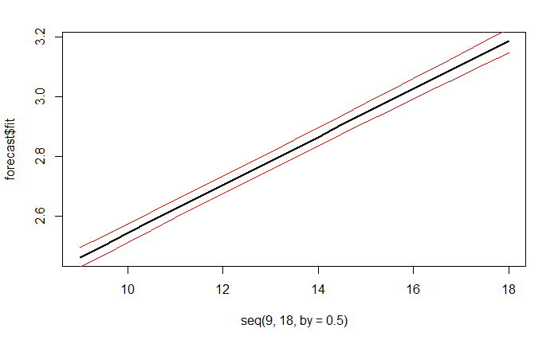

```r
lines(seq(9, 18, by = 0.5), forecast$fit - 2 * forecast$se.fit, type = "l", col = "red", lwd = 1.5)
```

2. Load the data set **bsp4.txt**.

```r
bsp4 <- read.csv("../../data/bsp4.txt")
head(bsp4)
```

|  | y | x |
| --- | --- | --- |
| 1 | 20.40 | 20.23 |
| 2 | 218.92 | 66.01 |
| 3 | 189.06 | 64.83 |
| 4 | 197.56 | 66.10 |
| 5 | 304.33 | 87.48 |
| 6 | 281.04 | 67.63 |

- Plot the scatter plot of $y$ against $x$.

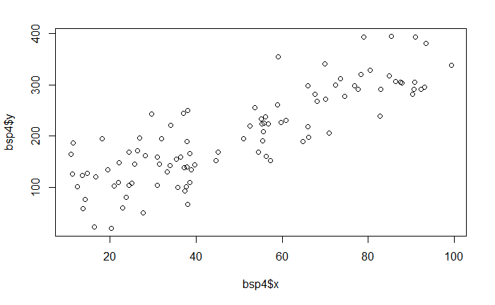

```r
plot(bsp4$x, bsp4$y)
```

- Perform a simple linear regression of $y$ on $x$ and save the results as an `lm`-object `obj`. Add the regression line of $y$ on $x$ to the plot.

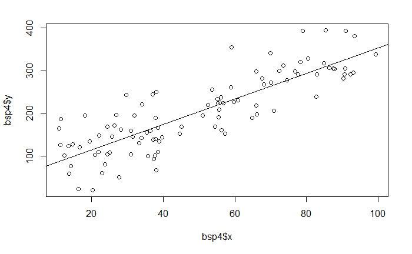

```r
plot(bsp4$x, bsp4$y)
obj <- lm(bsp4$y ~ bsp4$x)
abline(obj)
```

- Extract the fitted values from `obj` and add them as red points to the plot (use the command `points`).

```r
plot(bsp4$x, bsp4$y)
abline(obj)
```

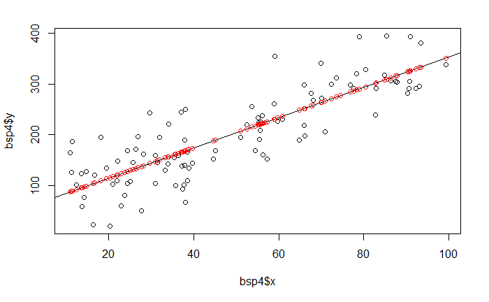

```r
points(bsp4$x, obj$fitted.values, col = "red")
```

- Extract the residuals of the regression and calculate the sum of the squared residuals, $SSR=\sum_{i=1}^{100}\hat{u}_{i}^{2}$

```r
ssr <- sum((obj$residuals)^2)
print(ssr)
```

```
[1] 223587.4
```

- Compute the total sum of squares and the explained sum of squares,
  $$\begin{align*}
  TSS &=\sum_{i=1}^{100}\left( y_{i}-\bar{y}\right) ^{2} \\
  ESS &=\sum_{i=1}^{100}\left( \hat{y}_{i}-\bar{y}\right) ^{2}
  \end{align*}$$
  and show that $ESS+SSR=TSS$.

```r
tss <- sum((bsp4$y - mean(bsp4$y))^2)
ess <- sum((obj$fitted.values - mean(bsp4$y))^2)
ess + ssr - tss # this is numerically zero
```

```
[1] -1.164153e-10
```

```r
round(ess + ssr) == round(tss)
```

```
[1] TRUE
```

# 24 Numerical optimization

1. Define the polynomial `function`
   $$\begin{equation*}
   f(x)=x\left( x-2\right) \left( x-4\right) \left( x-5\right) -10
   \end{equation*}$$
   and plot it over the interval $[0,5]$.

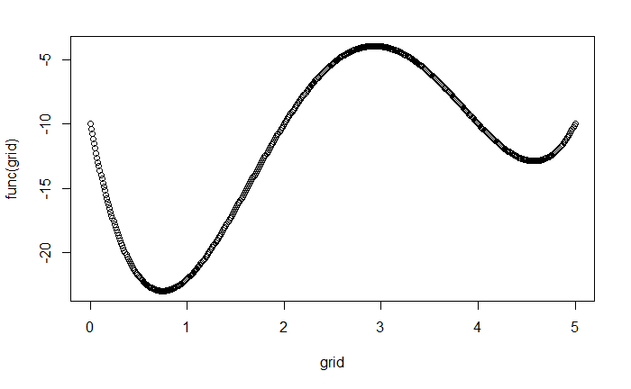

```r
func <- function(x) {
    out <- x * (x - 2) * (x - 4) * (x - 5) - 10
    return(out)
}
grid <- seq(0, 5, by=0.01)
plot(grid, func(grid))
```

- Use `optimize` to find the minimum of the function. Set the interval to $[0,5]$ and then to $[0,6].$

```r
optimize(func, c(0, 5)) # global minimum
```

```
$minimum
[1] 0.7462542

$objective
[1] -22.94945
```

```r
optimize(func, c(0, 6)) # local minimum
```

```
$minimum
[1] 4.574215

$objective
[1] -12.8789
```

```r
optimize(func, c(-1000,1000)) #global minimum
```

```
$minimum
[1] 0.7462488

$objective
[1] -22.94945
```

- Even though one-dimensional optimization problems should be solved by `optimize`, use the `optim`-command with option `method="BFGS"` to find the minimum of the function $f$. Set the starting values to $0,1,2,3,-1$ and check if the algorithm finds the global minimum.

```r
optim(0, func, method = "BFGS")   # global minimum
```

```
$par
[1] 0.7462236

$value
[1] -22.94945

$counts
function gradient
      15        7

$convergence
[1] 0

$message
NULL
```

```r
optim(1, func, method = "BFGS")   # global minimum
```

```
$par
[1] 0.7462166

$value
[1] -22.94945

$counts
function gradient
       9        4

$convergence
[1] 0

$message
NULL
```

```r
optim(2, func, method = "BFGS")   # global minimum
```

```
$par
[1] 0.7462516

$value
[1] -22.94945

$counts
function gradient
      18        8

$convergence
[1] 0

$message
NULL
```

```r
optim(3, func, method = "BFGS")   # local minimum
```

```
$par
[1] 4.574214

$value
[1] -12.8789

$counts
function gradient
      20        7

$convergence
[1] 0

$message
NULL
```

```r
optim(-1, func, method = "BFGS")  # local minimum
```

```
$par
[1] 4.574214

$value
[1] -12.8789

$counts
function gradient
      14        7

$convergence
[1] 0

$message
NULL
```

2. Consider the Cobb-Douglas production function with two inputs $x_{1}$ and $x_{2}$,
   $$\begin{align*}
   y=f(x_{1},x_{2})=x_{1}^{0.3}x_{2}^{0.6}.
   \end{align*}$$
   Suppose the output price is $p_{y}=1$ and the input prices are $p_{1}=2$ and $p_{2}=0.5$. Define the profit function as a `function` and numerically maximize it.

```r
negprofit <- function(x, pr = c(1,2,0.5)) {
  x1 <- x[1]
  x2 <- x[2]
  py <- pr[1]
  p1 <- pr[2]
  p2 <- pr[3]
  profit <- py * (x1^0.3*x2^0.6) - p1 * x1 - p2 * x2
  return(-profit) # optim minimizes function, so we minimize the negative profits
}
x0 <- c(0,0)
pr0 <- c(1,2,0.5)
res <- optim(x0, negprofit, pr=pr0, control = c(maxit=50))
print(res) # note that convergence code is 1, we should increase maximum number of iterations maxit
```

```
$par
[1] 0.001500856 0.012013937

$value
[1] -0.001007749

$counts
function gradient
      51       NA

$convergence
[1] 1

$message
NULL
```

```r
res <- optim(x0, negprofit, pr=pr0, control = c(maxit=500))
print(res)
```

```
$par
[1] 0.001511654 0.012093231

$value
[1] -0.00100777

$counts
function gradient
     109       NA

$convergence
[1] 0

$message
NULL
```

```r
print(paste("The maximum profit is equal to",round(-res$value,digits=5)))
```

```
[1] "The maximum profit is equal to 0.00101"
```

```r
expgrowth <- read.csv("../../data/expgrowth.csv")
head(expgrowth)
```

|  | y | x |
| --- | --- | --- |
| 1 | 18.77 | 19.40 |
| 2 | 6.90 | 5.67 |
| 3 | 12.15 | 13.95 |
| 4 | 9.58 | 9.27 |
| 5 | 8.29 | 1.23 |
| 6 | 22.60 | 21.74 |

```r
fn <- function(param,dat) {
  alph <- param[1]
  bet <- param[2]
  y <- dat$y
  x <- dat$x
  u <- y - exp(alph + bet * x)
  out <- sum(u^2)
  return(out)
}
param0 <- c(0,0)
optim(param0, fn, dat=expgrowth)
```

```
$par
[1] 1.96128206 0.05097611

$value
[1] 841.4999

$counts
function gradient
      75       NA

$convergence
[1] 0

$message
NULL
```

# 25 Maximum likelihood

1. Load the data set **round86.csv** into a data frame. The first column is the actual earnings in 1986 of $n=443$ persons as derived from the employers files, the second column is the earnings reported by the persons.

```r
round86 <- read.csv("../../data/round86.csv")
actual <- round86$actual
reported <- round86$reported
head(round86)
```

|  | actual | reported |
| --- | --- | --- |
| 1 | 31516 | 31450 |
| 2 | 37261 | 37000 |
| 3 | 36012 | 35000 |
| 4 | 37827 | 35000 |
| 5 | 37339 | 38538 |
| 6 | 35396 | 30000 |

- Compute the reporting errors and plot their histogram.

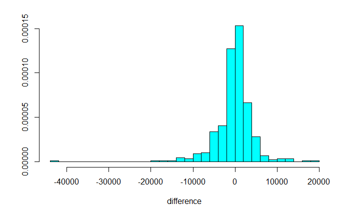

```r
difference <- actual - reported
library(MASS)
truehist(difference)
```

- Assume that the reporting error $x$ follows a Laplace distribution with density
  $$f\left( x\right) =\frac{1}{2b}\exp \left( -\frac{|x-\mu |}{b}\right)$$
  Write a function of $\theta =(\mu ,b)$ and $x=(x_{1},\ldots ,x_{n})$ to compute the log-likelihood function
  $$\ln L\left( \theta ,x\right) =\sum_{i=1}^{n}\ln f\left( x\right)$$
  Hint: The absolute value function $|\cdot |$ is `abs()`.

```r
laplace <- function(param, gap) {
  mu <- param[1]
  b <- param[2]
  f <- log(1/(2 * b)) - abs(gap - mu)/b
  out <- sum(f)
  return(-out)
}
```

- Numerically maximize the log-likelihood function with respect to $\mu$ and $b$. Set the starting values to $\mu _{0}=0$ and $b_{0}=3000$.

```r
param0 <- c(0, 3000)
optim(param0, laplace, gap=difference)
```

```
$par
[1]   55.79285 2739.59867

$value
[1] 4256.621

$counts
function gradient
      47       NA

$convergence
[1] 0

$message
NULL
```

2. Load the data set **fussballdaten.csv** into a data frame.

```r
fussballdaten <- read.csv2("../../data/fussballdaten.csv")
head(fussballdaten)
```

|  | Saison | Sptag | Heim | Auswaerts | ToreH | ToreA | TorminH | TorminA | GelbH | GelbRotH | RotH | MinH | GelbA | GelbRotA | RotA | MinA |
| --- | --- | --- | --- | --- | --- | --- | --- | --- | --- | --- | --- | --- | --- | --- | --- | --- |
| 1 | 1996 | 1 | bremen | duesseldorf | 1 | 1 | 22 | 2 | 2 | 0 | 0 |  | 5 | 0 | 0 |  |
| 2 | 1996 | 1 | dortmund | klautern | 1 | 1 | 72 | 74 | 1 | 0 | 0 |  | 4 | 1 | 0 | 60 |
| 3 | 1996 | 1 | vfbstuttgart | uerdingen | 0 | 0 |  |  | 2 | 0 | 0 |  | 2 | 0 | 0 |  |
| 4 | 1996 | 1 | frankfurt | karlsruhe | 2 | 2 | 43/71 | 8/47 | 1 | 0 | 0 |  | 1 | 0 | 0 |  |
| 5 | 1996 | 1 | fckoeln | schalke | 0 | 1 |  | 75 | 3 | 0 | 0 |  | 3 | 0 | 0 |  |
| 6 | 1996 | 1 | bmuenchen | hamburg | 3 | 2 | 31/51/69 | 2/75 | 1 | 0 | 0 |  | 4 | 0 | 0 |  |

```r
homedortmund <- fussballdaten$ToreH[fussballdaten$Heim == "dortmund"]
table(homedortmund)
```

```
homedortmund
 0  1  2  3  4  5  6
29 73 60 38 12  4  5
```

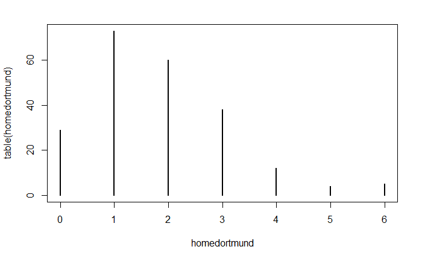

```r
plot(table(homedortmund))
```

- Fit a Poisson distribution to the number of goals. The maximum likelihood estimator of the parameter $\lambda$ of the Poisson distribution is $\hat{\lambda}=\bar{X}$ where $\bar{X}$ is the mean number of goals. Add the probabilities of the fitted Poisson distribution to the plot (as red points).

```r
plot(table(homedortmund))
lines(seq(0, 6), dpois(seq(0, 6), lambda = mean(homedortmund)) * length(homedortmund))
```

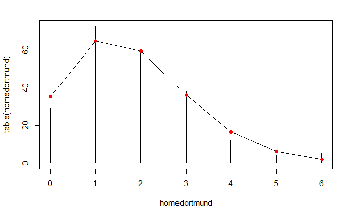

```r
points(seq(0, 6), dpois(seq(0, 6), lambda = mean(homedortmund)) * length(homedortmund), col = "red", pch = 19)
```

3. Let $X\sim LN(\mu,\sigma^{2})$ and let $X_{1},...,X_{n}$ be a sample drawn from $X$. The $X_{i}$ are not observable. Instead one can only observe
   $$Y_{i}=\left\{
   \begin{array}{ll}
   X_{i} & \quad \text{if }X_{i}<c \\
   c & \quad \text{if }X_{i}\geq c
   \end{array}
   \right.$$
   where $c$ is a known constant. The likelihood of $Y_{1},...,Y_{n}$ is the product of all densities $f_{X}(y_{i}),$ for observations with $Y_{i}<c$, times the product of all probabilities that $Y_{i}=c$ for observations with $Y_{i}=c$.

Let’s consider the probability of $Y_i=c$:
$$Pr(Y_i = c) = Pr(X_i \geq c) = 1 - Pr(X_i \leq c) = 1- F_X(c)$$
The likelihood function is now a mixture between the product of all densities $f_{X}(y_{i})$ for observations with $Y_{i}<c$, times the product of all probabilities that $Y_{i}=c$ for observations with $Y_{i}=c$:
$$L(\mu,\sigma; y) = \prod_{i=1}^n\{ f_X(y_i;\mu,\sigma)\}^{\delta_i}\{1-F_X(c;\mu,\sigma)\}^{1-\delta_i}$$
with $\delta_i=1$ for exact observations and $\delta_i=0$ for a censored observation. The log likelihood is thus the sum of those two components. Let $n_1$ be the number of non-censored observations and $n_2$ the number of censored observations, $n_1+n_2=n$, then:
$$\log L(\mu,\sigma; y) = \sum_{i=1}^{n_1} \log f_X(y_i;\mu,\sigma) +
\sum_{i=1}^{n_2} \log(1-F_X(c;\mu,\sigma))$$

- Load the data set **censoredln.csv**.

```r
censoredln <- read.csv("../../data/censoredln.csv")
head(censoredln)
```

|  | x |
| --- | --- |
| 1 | 4.46588 |
| 2 | 9.38127 |
| 3 | 12.00000 |
| 4 | 2.52730 |
| 5 | 10.12049 |
| 6 | 10.51737 |

```r
x <- censoredln$x
```

- Write an R function `neglogl <- function(param,dat,cens)` that computes the negative log-likelihood function. `param` = ($\mu$, $\sigma^{2}$), `dat` contains the observations $Y_{1},...,Y_{n}$ and $cens$ is the censoring value $c$.

```r
neglogl <- function(param,dat,cens) {
  mu <- param[1]
  sigm <- param[2]
  logl <- sum(log(dlnorm(dat[dat<cens],meanlog=mu,sdlog=sigm)))
  + sum(log(1-plnorm(dat[dat==cens],meanlog=mu,sdlog=sigm)))
  return(-logl)
}
```

- Numerically maximize the likelihood function. The censoring value is $c=12$.

```r
param0 <- c(0,1)
cens0 <- 12
obj <- optim(param0,neglogl,dat=x,cens=cens0,hessian=T,control = c(maxit=500))
print(obj)
```

```
$par
[1] 1.9097510 0.3802799

$value
[1] 935.0325

$counts
function gradient
      75       NA

$convergence
[1] 0

$message
NULL

$hessian
            [,1]        [,2]
[1,] 2738.347391   -1.469883
[2,]   -1.469883 5468.056380
```

- Compute the asymptotic covariance matrix of $\hat{\mu}$ and $\hat{\sigma}^{2}$.

```r
solve(obj$hessian)
```

```
             [,1]         [,2]
[1,] 3.651838e-04 9.816604e-08
[2,] 9.816604e-08 1.828804e-04
```

# 26 Dates and times

```r
as.Date("1989-11-09")
```

```
[1] "1989-11-09"
```

- November 9th, 1989

```r
as.Date("1989-11-09")
```

```
[1] "1989-11-09"
```

- All Wednesdays in 2012

```r
# simple solution: set first Wednesday and then add weekly
seq(as.Date("2012-01-04"), as.Date("2012-12-26"), by = "week")
```

```
 [1] "2012-01-04" "2012-01-11" "2012-01-18" "2012-01-25" "2012-02-01" "2012-02-08"
 [7] "2012-02-15" "2012-02-22" "2012-02-29" "2012-03-07" "2012-03-14" "2012-03-21"
[13] "2012-03-28" "2012-04-04" "2012-04-11" "2012-04-18" "2012-04-25" "2012-05-02"
[19] "2012-05-09" "2012-05-16" "2012-05-23" "2012-05-30" "2012-06-06" "2012-06-13"
[25] "2012-06-20" "2012-06-27" "2012-07-04" "2012-07-11" "2012-07-18" "2012-07-25"
[31] "2012-08-01" "2012-08-08" "2012-08-15" "2012-08-22" "2012-08-29" "2012-09-05"
[37] "2012-09-12" "2012-09-19" "2012-09-26" "2012-10-03" "2012-10-10" "2012-10-17"
[43] "2012-10-24" "2012-10-31" "2012-11-07" "2012-11-14" "2012-11-21" "2012-11-28"
[49] "2012-12-05" "2012-12-12" "2012-12-19" "2012-12-26"
```

```r
# alternatively: generate vector of all days in 2012 and look for wednesday
a <- seq(as.Date("2012-01-01"), as.Date("2012-12-31"), by = "days");
a[weekdays(a) == "Mittwoch"]
```

```
 [1] "2012-01-04" "2012-01-11" "2012-01-18" "2012-01-25" "2012-02-01" "2012-02-08"
 [7] "2012-02-15" "2012-02-22" "2012-02-29" "2012-03-07" "2012-03-14" "2012-03-21"
[13] "2012-03-28" "2012-04-04" "2012-04-11" "2012-04-18" "2012-04-25" "2012-05-02"
[19] "2012-05-09" "2012-05-16" "2012-05-23" "2012-05-30" "2012-06-06" "2012-06-13"
[25] "2012-06-20" "2012-06-27" "2012-07-04" "2012-07-11" "2012-07-18" "2012-07-25"
[31] "2012-08-01" "2012-08-08" "2012-08-15" "2012-08-22" "2012-08-29" "2012-09-05"
[37] "2012-09-12" "2012-09-19" "2012-09-26" "2012-10-03" "2012-10-10" "2012-10-17"
[43] "2012-10-24" "2012-10-31" "2012-11-07" "2012-11-14" "2012-11-21" "2012-11-28"
[49] "2012-12-05" "2012-12-12" "2012-12-19" "2012-12-26"
```

- The first days of all months from January 2005 to December 2011

```r
seq(as.Date("2005-01-01"), as.Date("2011-12-31"), by = "month")
```

```
 [1] "2005-01-01" "2005-02-01" "2005-03-01" "2005-04-01" "2005-05-01" "2005-06-01"
 [7] "2005-07-01" "2005-08-01" "2005-09-01" "2005-10-01" "2005-11-01" "2005-12-01"
[13] "2006-01-01" "2006-02-01" "2006-03-01" "2006-04-01" "2006-05-01" "2006-06-01"
[19] "2006-07-01" "2006-08-01" "2006-09-01" "2006-10-01" "2006-11-01" "2006-12-01"
[25] "2007-01-01" "2007-02-01" "2007-03-01" "2007-04-01" "2007-05-01" "2007-06-01"
[31] "2007-07-01" "2007-08-01" "2007-09-01" "2007-10-01" "2007-11-01" "2007-12-01"
[37] "2008-01-01" "2008-02-01" "2008-03-01" "2008-04-01" "2008-05-01" "2008-06-01"
[43] "2008-07-01" "2008-08-01" "2008-09-01" "2008-10-01" "2008-11-01" "2008-12-01"
[49] "2009-01-01" "2009-02-01" "2009-03-01" "2009-04-01" "2009-05-01" "2009-06-01"
[55] "2009-07-01" "2009-08-01" "2009-09-01" "2009-10-01" "2009-11-01" "2009-12-01"
[61] "2010-01-01" "2010-02-01" "2010-03-01" "2010-04-01" "2010-05-01" "2010-06-01"
[67] "2010-07-01" "2010-08-01" "2010-09-01" "2010-10-01" "2010-11-01" "2010-12-01"
[73] "2011-01-01" "2011-02-01" "2011-03-01" "2011-04-01" "2011-05-01" "2011-06-01"
[79] "2011-07-01" "2011-08-01" "2011-09-01" "2011-10-01" "2011-11-01" "2011-12-01"
```

- The first days of all quarters from April 2000 to January 2012

```r
seq(as.Date("2000-04-01"), as.Date("2012-01-31"), by = "3 months")
```

```
 [1] "2000-04-01" "2000-07-01" "2000-10-01" "2001-01-01" "2001-04-01" "2001-07-01"
 [7] "2001-10-01" "2002-01-01" "2002-04-01" "2002-07-01" "2002-10-01" "2003-01-01"
[13] "2003-04-01" "2003-07-01" "2003-10-01" "2004-01-01" "2004-04-01" "2004-07-01"
[19] "2004-10-01" "2005-01-01" "2005-04-01" "2005-07-01" "2005-10-01" "2006-01-01"
[25] "2006-04-01" "2006-07-01" "2006-10-01" "2007-01-01" "2007-04-01" "2007-07-01"
[31] "2007-10-01" "2008-01-01" "2008-04-01" "2008-07-01" "2008-10-01" "2009-01-01"
[37] "2009-04-01" "2009-07-01" "2009-10-01" "2010-01-01" "2010-04-01" "2010-07-01"
[43] "2010-10-01" "2011-01-01" "2011-04-01" "2011-07-01" "2011-10-01" "2012-01-01"
```

- Use `difftime` to compute the number of days between your date of birth and today

```r
difftime(as.Date("2018-03-29"), as.Date("1986-05-24"), units = "days")
```

```
Time difference of 11632 days
```

2. Use the command `strptime` to generate the following dates and times or vectors of dates and times of class `POSIXlt`:
- January 19th, 2012, 08:45:00

```r
staart <- strptime("2012/01/19-08:45:00", "%Y/%m/%d-%H:%M:%S")
```

- January 19th, 2012, 12:00:00

```r
eend <- strptime("2012/01/19-12:00:00", "%Y/%m/%d-%H:%M:%S")
```

- All minutes between the times in the above two dates

```r
seq(staart, eend, by = "mins")
```

```
  [1] "2012-01-19 08:45:00 CET" "2012-01-19 08:46:00 CET" "2012-01-19 08:47:00 CET"
  [4] "2012-01-19 08:48:00 CET" "2012-01-19 08:49:00 CET" "2012-01-19 08:50:00 CET"
  [7] "2012-01-19 08:51:00 CET" "2012-01-19 08:52:00 CET" "2012-01-19 08:53:00 CET"
 [10] "2012-01-19 08:54:00 CET" "2012-01-19 08:55:00 CET" "2012-01-19 08:56:00 CET"
 [13] "2012-01-19 08:57:00 CET" "2012-01-19 08:58:00 CET" "2012-01-19 08:59:00 CET"
 [16] "2012-01-19 09:00:00 CET" "2012-01-19 09:01:00 CET" "2012-01-19 09:02:00 CET"
 [19] "2012-01-19 09:03:00 CET" "2012-01-19 09:04:00 CET" "2012-01-19 09:05:00 CET"
 [22] "2012-01-19 09:06:00 CET" "2012-01-19 09:07:00 CET" "2012-01-19 09:08:00 CET"
 [25] "2012-01-19 09:09:00 CET" "2012-01-19 09:10:00 CET" "2012-01-19 09:11:00 CET"
 [28] "2012-01-19 09:12:00 CET" "2012-01-19 09:13:00 CET" "2012-01-19 09:14:00 CET"
 [31] "2012-01-19 09:15:00 CET" "2012-01-19 09:16:00 CET" "2012-01-19 09:17:00 CET"
 [34] "2012-01-19 09:18:00 CET" "2012-01-19 09:19:00 CET" "2012-01-19 09:20:00 CET"
 [37] "2012-01-19 09:21:00 CET" "2012-01-19 09:22:00 CET" "2012-01-19 09:23:00 CET"
 [40] "2012-01-19 09:24:00 CET" "2012-01-19 09:25:00 CET" "2012-01-19 09:26:00 CET"
 [43] "2012-01-19 09:27:00 CET" "2012-01-19 09:28:00 CET" "2012-01-19 09:29:00 CET"
```

[output cut: 51 more lines]

- What happens if you add 1 to a `POSIXlt` object?

```r
strptime("2012/01/19-08:45:00", "%Y/%m/%d-%H:%M:%S") + 1
```

```
[1] "2012-01-19 08:45:01 CET"
```

3. Load the data set **indices.csv** into a data frame.

```r
indices <- read.csv("../../data/indices.csv")
```

- Use the command `strptime` to convert the first column of the data frame into a vector of class `POSIXlt`.

```r
dates <- strptime(indices$date, "%d.%m.%Y")
```

- Plot the DAX index as a black line against the date vector.

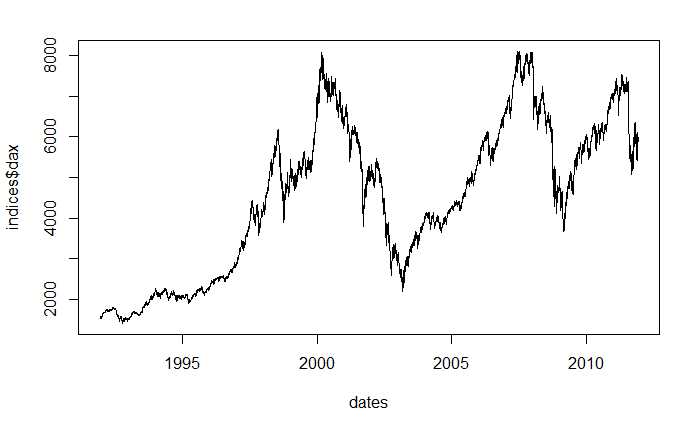

```r
plot(dates, indices$dax, type = "l")
```

- Compute the daily returns of the DAX index,
  $$r_{t}=\ln \frac{DAX_{t}}{DAX_{t-1}}$$
  and calculate the mean return for each weekday. Plot the mean returns for each weekday as a bar chart.

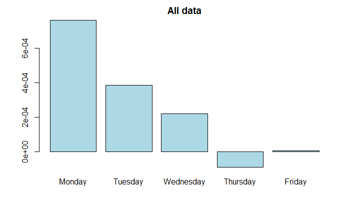

```r
n <- length(indices$dax)
ret <- log(indices$dax[-1]/indices$dax[-n])  # to get returns we get rid of first observation
dates1 <- dates[-1]  # get rid of first observation in date vector
mo <- mean(ret[weekdays(dates1) == "Montag"])
di <- mean(ret[weekdays(dates1) == "Dienstag"])
mi <- mean(ret[weekdays(dates1) == "Mittwoch"])
do <- mean(ret[weekdays(dates1) == "Donnerstag"])
fr <- mean(ret[weekdays(dates1) == "Freitag"])
barplot(c(mo, di, mi, do, fr), col = "lightblue", names = c("Monday", "Tuesday", "Wednesday", "Thursday", "Friday"), main = "All data")
```

- Use the function `holiday` of the `timeDate` package to identify the holidays at Deutsche Börse. Remove the holiday returns and redo the computations for the weekday returns.

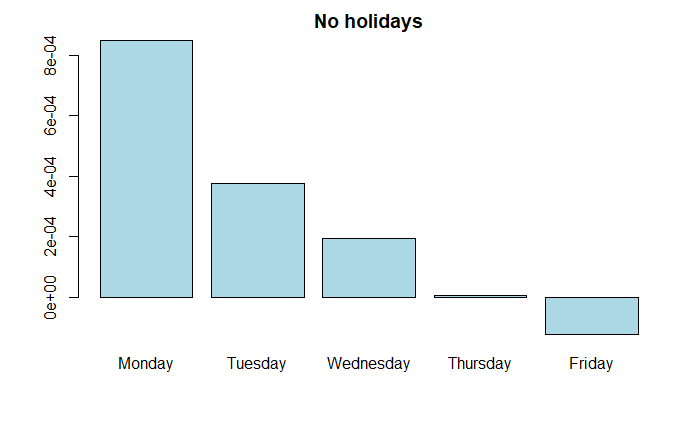

```r
library(timeDate)
holidays <- strptime(holiday(1991:2012, c("Easter", "DEAscension", "DECorpusChristi", "DEGermanUnity", "DEChristmasEve", "DENewYearsEve", "NewYearsDay")), "%Y-%m-%d")  # all german holidays
d <- !dates %in% holidays  # logical vector for all non-holiday days
indicesnew <- indices[d, ]  # data of non-holiday days
n2 <- length(indicesnew$dax)
dates2 <- strptime(indicesnew$date, "%d.%m.%Y")
dates2 <- dates2[-1]  # remove first observation as we are computing returns
ret2 <- log(indicesnew$dax[-1]/indicesnew$dax[-n2]) # compute returns
mo <- mean(ret2[weekdays(dates2) == "Montag"])
di <- mean(ret2[weekdays(dates2) == "Dienstag"])
mi <- mean(ret2[weekdays(dates2) == "Mittwoch"])
do <- mean(ret2[weekdays(dates2) == "Donnerstag"])
fr <- mean(ret2[weekdays(dates2) == "Freitag"])
barplot(c(mo, di, mi, do, fr), col = "lightblue", names = c("Monday", "Tuesday", "Wednesday", "Thursday", "Friday"), main = "No holidays")
```

# 27 Time series: Basics

Activate the package.

```r
library(zoo)
```

1. Load the dataset **BIP.csv** into a dataframe. The first column is the GDP in current prices, the second column is the price deflated (chain) index of GDP with 2005=100.

```r
BIP <- read.csv("../../data/BIP.csv")
head(BIP)
```

|  | BIP.current.pr | BIP.2005.100 |
| --- | --- | --- |
| 1 | 497.52 | 94.73 |
| 2 | 505.03 | 96.83 |
| 3 | 519.79 | 98.81 |
| 4 | 525.16 | 97.93 |
| 5 | 510.83 | 96.83 |
| 6 | 516.51 | 98.16 |

- The first observation is the first quarter of 2000, the last observation is the third quarter of 2011. Create a `ts` time series object of the GDP in current prices.

```r
gdp <- ts(BIP[, 1], start = c(2000, 1), frequency = 4)
```

- Print the time series.

```r
print(gdp)
```

```
       Qtr1   Qtr2   Qtr3   Qtr4
2000 497.52 505.03 519.79 525.16
2001 510.83 516.51 532.11 542.45
2002 514.63 523.91 546.14 547.52
2003 519.98 525.43 550.37 551.72
2004 534.55 541.03 558.84 561.28
2005 534.93 550.54 568.68 570.25
2006 558.61 566.02 590.47 598.80
2007 591.42 594.26 620.60 622.22
2008 608.52 618.08 631.67 615.53
2009 573.67 577.74 608.81 614.28
2010 594.78 607.02 635.41 639.59
2011 626.50 630.45 657.70
```

- Plot the time series.

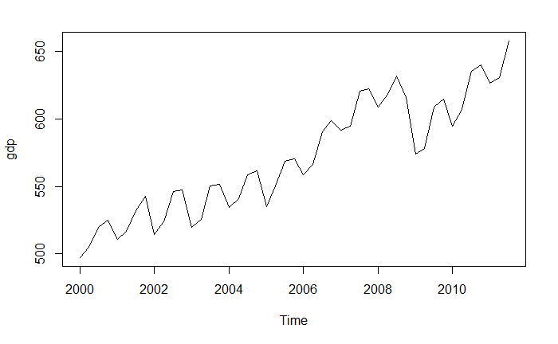

```r
plot(gdp)
```

- Use the command `rollmean` to add a moving average of length `k=4` to the plot.

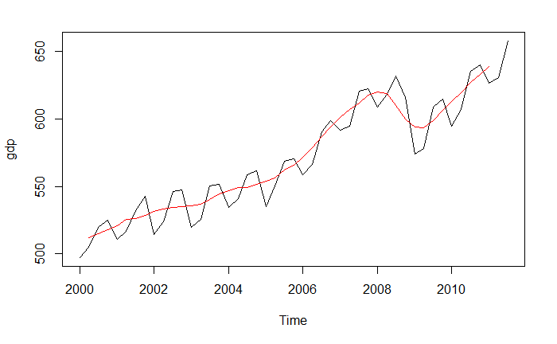

```r
plot(gdp)
lines(rollmean(gdp, k = 4), col = "red")
```

- Plot the time series of the differences between GDP and the rolling mean.

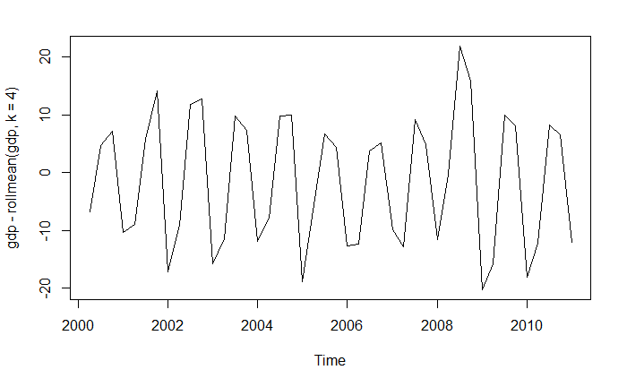

```r
plot(gdp - rollmean(gdp, k = 4))
```

- Use the function `aggregate` with option `nfrequency=1` to compute the time series of the annual GDP values.

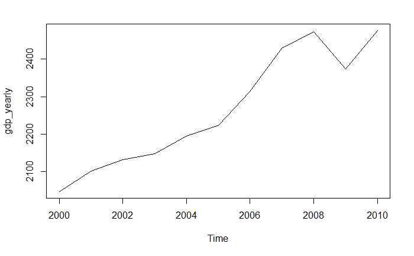

```r
gdp_yearly <- aggregate(gdp, nfrequency = 1)
plot(gdp_yearly)
```

- Plot the differences of the logarithm of the annual GDP values (i.e. the annual growth rates).

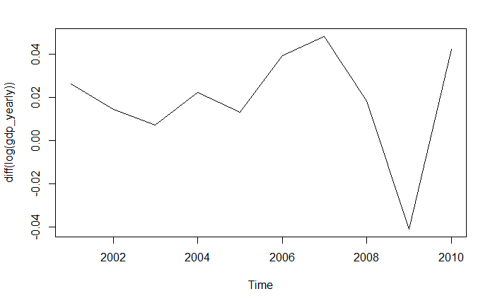

```r
plot(diff(log(gdp_yearly)))
```

2. Load the dataset **m3.csv** into a dataframe. It contains the money aggregate M3 for the Euro area. Remember to set the option `as.is=TRUE` in the `read.csv` command.

```r
M3 <- read.csv("../../data/m3.csv", as.is = T)
head(M3)
```

|  | Month | M3 |
| --- | --- | --- |
| 1 | 1980-1-1 | 1107.1 |
| 2 | 1980-2-1 | 1107.4 |
| 3 | 1980-3-1 | 1119.5 |
| 4 | 1980-4-1 | 1121.7 |
| 5 | 1980-5-1 | 1127.6 |
| 6 | 1980-6-1 | 1142.4 |

- Create a `zoo` object of the M3 time series.

```r
dates <- strptime(M3$Month, "%Y-%m-%d")
m3 <- zoo(M3$M3, order.by = dates)
```

- Print the time series, setting the option `style` to each of its three possible values, i.e. `horizontal`, `vertical`, and `plain`.

```r
print(head(m3), style = "horizontal")
```

```
1980-01-01 1980-02-01 1980-03-01 1980-04-01 1980-05-01 1980-06-01
    1107.1     1107.4     1119.5     1121.7     1127.6     1142.4
```

```r
print(head(m3), style = "vertical")
```

```
1980-01-01 1107.1
1980-02-01 1107.4
1980-03-01 1119.5
1980-04-01 1121.7
1980-05-01 1127.6
1980-06-01 1142.4
```

```r
print(head(m3), style = "plain")
```

```
Data:
[1] 1107.1 1107.4 1119.5 1121.7 1127.6 1142.4

Index:
[1] "1980-01-01 CET"  "1980-02-01 CET"  "1980-03-01 CET"
[4] "1980-04-01 CET"  "1980-05-01 CEST" "1980-06-01 CEST"
```

- Plot the time series and add the rolling mean (with window width 12 months) in red.

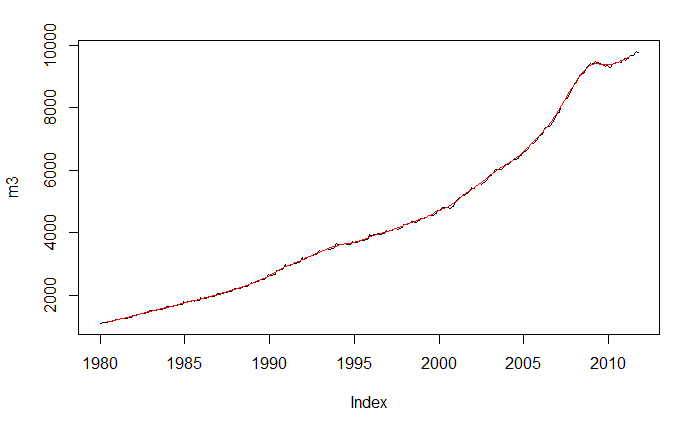

```r
plot(m3)
lines(rollmean(m3, k = 12), col = "red")
```

- Plot the deviation of the time series from its rolling mean.

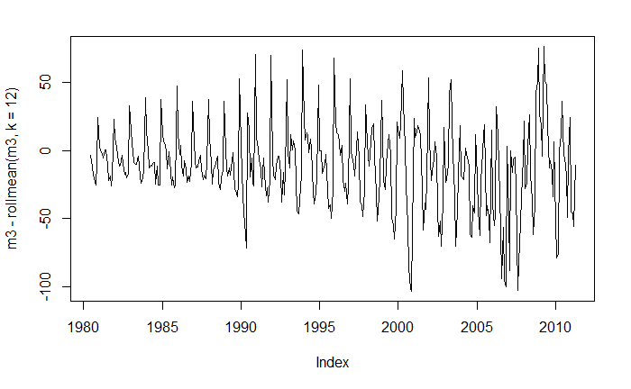

```r
plot(m3 - rollmean(m3, k = 12))
```

- Use the command `lag` to define the time series $M3_{t-12}$ (i.e. M3 in the same month of the previous year).

```r
m3_12 <- lag(m3, -12)
```

- Plot $M3_{t}-M3_{t-12}$ and $\ln M3_{t}-\ln M3_{t-12}$.

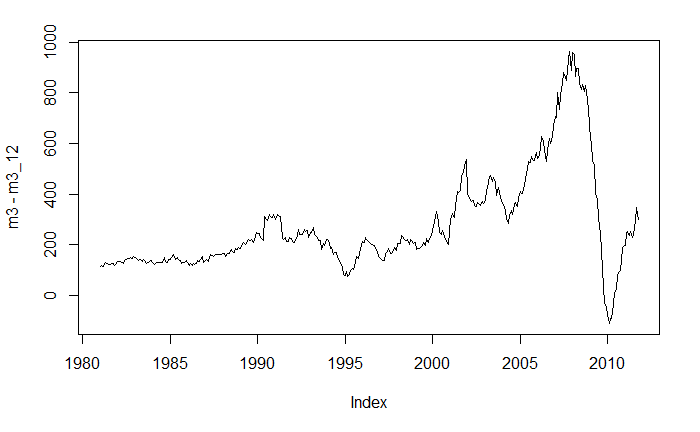

```r
plot(m3 - m3_12)  # deviations within a year
```

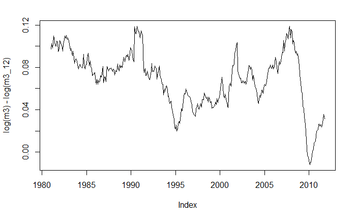

```r
plot(log(m3) - log(m3_12))
```

3. Convert the M3 time series to class `ts`.

```r
m3_ts <- ts(M3[, 2], start = c(1980, 1), frequency = 12)
```

- Read `?decompose`. Decompose the time series into a trend, a seasonal component, and a remainder term using the function `decompose`. Assign the function value to an object (which will be of class `decomposed.ts`), and plot this object.

```r
?decompose
decomp <- decompose(m3_ts)
class(decomp)
```

```
[1] "decomposed.ts"
```

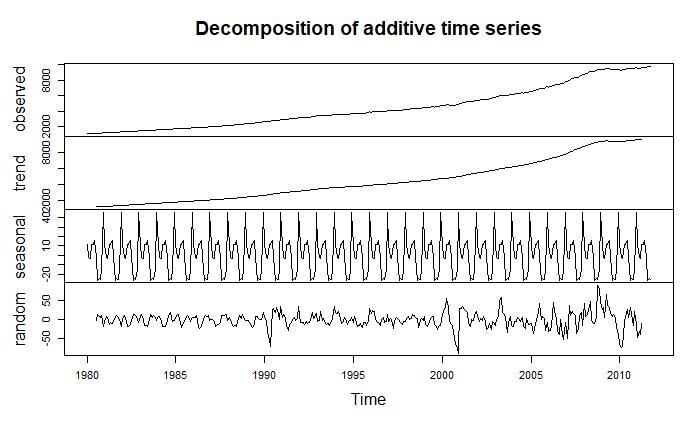

```r
plot(decomp) # default type is additive
```

- Try both `type` options (i.e. `additive` and `multiplicative`). Which one would you prefer?

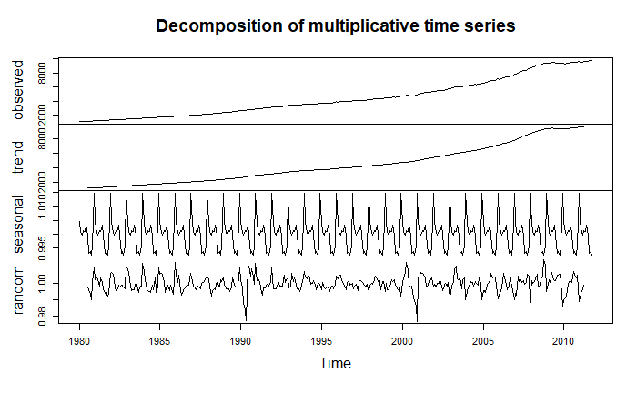

```r
decomp2 <- decompose(m3_ts, type = "multiplicative")
plot(decomp2)
```

4. Continue to use the M3 time series.
- Execute `acf(diff(M3))` and interpret the plot.

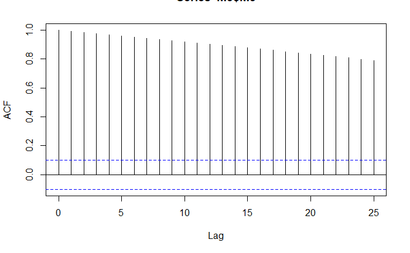

```r
acf(M3$M3) #time series is nonstationary
```

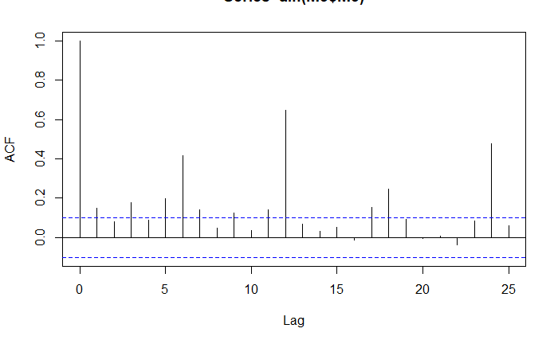

```r
acf(diff(M3$M3))  # strong seasonality within the first differences
```

- Returns from the `acf` command are of class `acf`, see `?acf`. Extract the autocorrelations of `diff(M3)` as a vector.

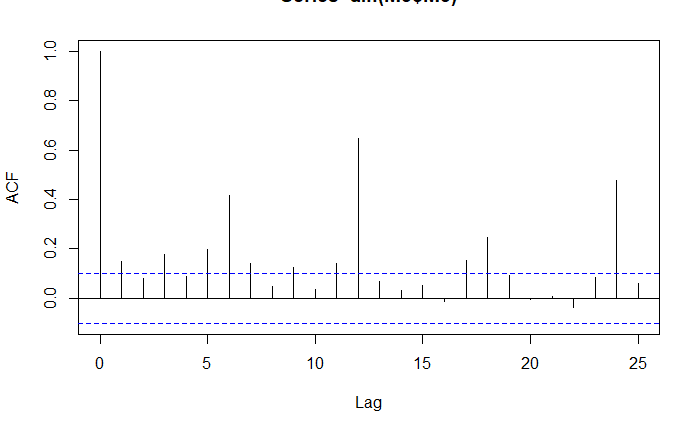

```r
autocorr <- acf(diff(M3$M3))$acf
```

5. Consider the dataset `electricity.csv`. It contains hourly electricity prices (in EUR/MWh) at the EEX.
- The time format is *YYYY-MM-DD, HH:00*. Read the dataset into a dataframe (using the option `as.is=TRUE`) and create a vector for the date-time information.

```r
elec <- read.csv("../../data/electricity.csv", as.is = TRUE)
head(elec)
```

|  | X2006.01.01 | X00.00 | X32.1 |
| --- | --- | --- | --- |
| 1 | 2006-01-01 | 01:00 | 30.07 |
| 2 | 2006-01-01 | 02:00 | 27.94 |
| 3 | 2006-01-01 | 03:00 | 21.71 |
| 4 | 2006-01-01 | 04:00 | 8.24 |
| 5 | 2006-01-01 | 05:00 | 1.13 |
| 6 | 2006-01-01 | 06:00 | 0.00 |

```r
datetime <- paste(elec[, 1], elec[, 2])
head(datetime)
```

```
[1] "2006-01-01  01:00" "2006-01-01  02:00" "2006-01-01  03:00"
[4] "2006-01-01  04:00" "2006-01-01  05:00" "2006-01-01  06:00"
```

```r
dat <- strptime(datetime, "%Y-%m-%d %H:%M")
```

- Plot the time series of the electricity prices.

[figure not shown]

- Use the `acf` command to compute and display the autocorrelation function up to lag order 750.

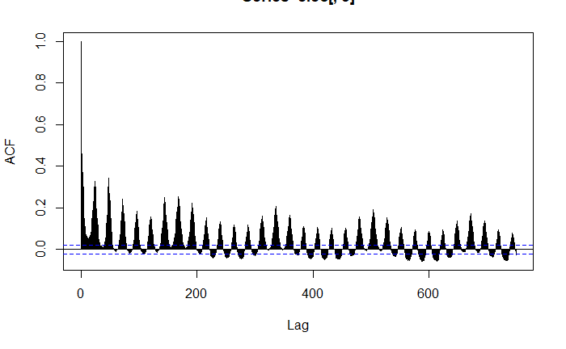

```r
acf(elec[, 3], lag.max = 750)
```

- Convert the price time series into an `ts` object with start date 1 and end date 365 (and, of course, frequency 24). Use the command `aggregate` to calculate the average daily prices.

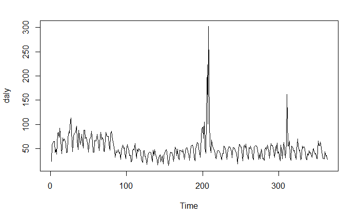

```r
tser2 <- ts(elec[, 3], start = 1, frequency = 24)
daly <- aggregate(tser2, nfrequency = 1, FUN = mean)  # nfrequency is new number of observations per unit of time
plot(daly)
```

# 28 Time series: Model estimation and unit roots

Activate the packages `tseries`, `fGarch`, and `vars`.

```r
library(tseries)
library(fGarch)
library(vars)
```

1. Load the artificial dataset **ar1.csv**. It contains two variables, the endogenous variable $Y$ and the exogenous variable $X$. The linear relationship $Y_{t}=\alpha +\beta X_{t}$ is disturbed by a first order autoregressive error term $u_{t}$ with
   $$u_{t}=\rho u_{t-1}+\varepsilon _{t}$$
   where $\varepsilon _{t}\sim N(0,\sigma^{2})$ and $|\rho|<1$.

```r
dat <- read.csv("../../data/ar1.csv")
head(dat)
```

|  | x | y |
| --- | --- | --- |
| 1 | 67.7 | 138.7 |
| 2 | 80.1 | 165.9 |
| 3 | 70.9 | 147.4 |
| 4 | 80.9 | 167.5 |
| 5 | 46.5 | 97.9 |
| 6 | 23.3 | 51.8 |

- Run an OLS regression of $Y$ on $X$ and put the residuals into a vector `uhat`.

```r
regr <- lm(dat$y ~ dat$x)
uhat <- regr$residuals
```

- Use the command `ar` to estimate the autoregression coeffcient $\rho$ and the variance $\sigma^{2}$.

```r
estim <- ar(uhat, aic = F, order = 1)  # AIC=T estimates the lag order p automatically
names(estim)
```

```
 [1] "order"        "ar"           "var.pred"     "x.mean"
 [5] "aic"          "n.used"       "order.max"    "partialacf"
 [9] "resid"        "method"       "series"       "frequency"
[13] "call"         "asy.var.coef"
```

```r
rhohat <- estim$ar
print(rhohat)
```

```
[1] 0.6843711
```

```r
sig2hat <- estim$var.pred
print(sig2hat)
```

```
[1] 1.316374
```

- Extract the standard error of $\hat{\rho}$. Is $\hat{\rho}$ significantly positive?

```r
# Standard error of rho
serhohat <- sqrt(estim$asy.var.coef) # asy.var.coef is the asymptotic covariance matrix
print(serhohat)
```

```
           [,1]
[1,] 0.07365364
```

```r
# t-test: H0: rho <= 0, H1: rho>0
tstat <- (rhohat - 0)/serhohat
print(tstat)
```

```
         [,1]
[1,] 9.291748
```

```r
alph <- 0.05
if (tstat < qt(1-alph, df = estim$n.used-1)) {
  print("H0 is not rejected, rhohat might be less or equal to 0")
} else {
  print("H0 is rejected, rhohat is significantly positive")
}
```

```
[1] "H0 is rejected, rhohat is significantly positive"
```

2. Load the dataset `BIP.csv` and convert the first column (i.e. GDP in current prices) to class `ts`.

```r
bip <- read.csv("../../data/BIP.csv")
bip1 <- ts(bip[, 1], start = c(2000, 1), frequency = 4)
```

- Use the command `decompose` to calculate the trend, the saisonal pattern and the remainder term of the time series.

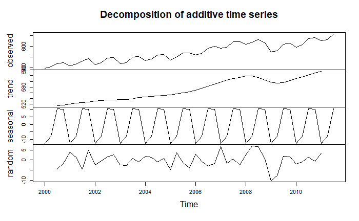

```r
bip2 <- decompose(bip1)
plot(bip2)
```

- Fit an AR(1) process to the remainder term (`$random`). In order to remove the missing values set the option `na.action=na.omit`.

```r
regr <- ar(bip2$random, aic = F, order = 1, na.action = na.omit)
print(regr)
```

```
Call:
ar(x = bip2$random, aic = F, order.max = 1, na.action = na.omit)

Coefficients:
     1
0.0591

Order selected 1  sigma^2 estimated as  13.36
```

- Test if the first order autocorrelation coefficient is significantly different from zero.

```r
tstat <- (regr$ar - 0)/sqrt(regr$asy.var.coef)
print(tstat)
```

```
          [,1]
[1,] 0.3794056
```

```r
# two-sided test: H0: rhohat=0 vs. H1 != 0
alph <- 0.05
if (abs(tstat) < qt(1-alph/2, df = regr$n.used-1)) {
  print("H0 is not rejected, rhohat might be equal to 0")
} else {
  print("H0 is rejected, rhohat is significantly different than 0")
}
```

```
[1] "H0 is not rejected, rhohat might be equal to 0"
```

- Now use the command `arima` to fit an AR(1) model to the remainder term.

```r
arima(bip2$random, order = c(1, 0, 0))
```

```
Call:
arima(x = bip2$random, order = c(1, 0, 0))

Coefficients:
         ar1  intercept
      0.0615    -0.0682
s.e.  0.1550     0.5790

sigma^2 estimated as 12.73:  log likelihood = -115.72,  aic = 237.44
```

- Fit an MA(1) model to the remainder term.

```r
arima(bip2$random, order = c(0, 0, 1))
```

```
Call:
arima(x = bip2$random, order = c(0, 0, 1))

Coefficients:
         ma1  intercept
      0.1270    -0.0700
s.e.  0.2048     0.6103

sigma^2 estimated as 12.68:  log likelihood = -115.62,  aic = 237.25
```

3. Load the dataset `investment.csv`. It contains the gross machinery investment (Bruttoausrüstungsinvestitionen) in current prices (in billion Euros).

```r
invest <- read.csv("../../data/investment.csv")
head(invest)
```

|  | year | investment |
| --- | --- | --- |
| 1 | 1970 | 35.53 |
| 2 | 1971 | 38.87 |
| 3 | 1972 | 38.69 |
| 4 | 1973 | 39.97 |
| 5 | 1974 | 38.47 |
| 6 | 1975 | 41.36 |

- Convert the investment time series to class `ts` and plot it in levels and percentage changes (differences of the logs). Ignore the structural break in 1990 due to Germany’s unification.

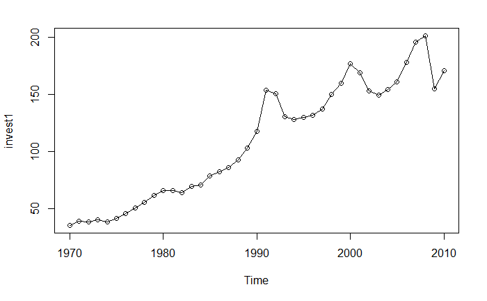

```r
invest1 <- ts(invest[, 2], start = 1970, frequency = 1)
plot(invest1, type = "o")
```

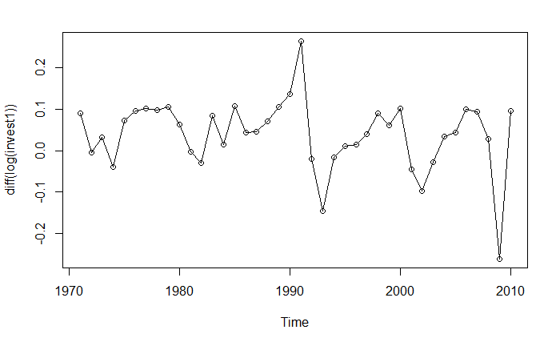

```r
plot(diff(log(invest1)), type = "o")
```

- Fit $ARIMA(p,1,q)$ models to the time series with $p,q\in \{0,1,2\}$. Find the lowest $AIC$ value of the 9 models.

```r
Z <- matrix(NA, 3, 3)
plag <- 0:2
qlag <- 0:2
for (ip in 1:3) {
  for (iq in 1:3) {
    Z[ip, iq] <- arima(invest1, order = c(plag[ip], 1, qlag[iq]))$aic
  }
}
print(Z)
```

```
         [,1]     [,2]     [,3]
[1,] 318.2948 319.2213 320.5288
[2,] 319.4881 320.9900 322.2895
[3,] 320.1873 322.0439 322.1495
```

```r
which.min(Z)
```

```
[1] 1
```

- Perform an $ADF$ test. Does investment exhibit a unit root?

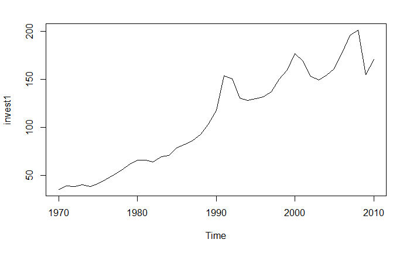

```r
plot(invest1)  # seems to be nonstationary
```

```r
testres <- adf.test(invest1)
print(testres)
```

```
    Augmented Dickey-Fuller Test

data:  invest1
Dickey-Fuller = -2.8763, Lag order = 3, p-value = 0.2289
alternative hypothesis: stationary
```

```r
alph <- 0.05
if (testres$p.value < alph) {
  print("The nullhypothesis of a unit root can be rejected. The time series is stationary.")
} else {
  print("The nullhypothesis of a unit root cannot be rejected. The time series seems to be nonstationary.")
}
```

```
[1] "The nullhypothesis of a unit root cannot be rejected. The time series seems to be nonstationary."
```

- Perform an $ADF$ test for the differenced time series of investment. Do the differences have a unit root?

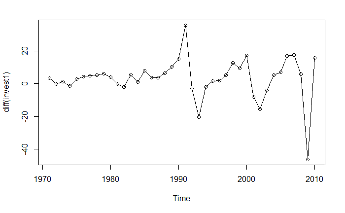

```r
library(tseries)
plot(diff(invest1), type = "o")
```

```r
testres1 <- adf.test(diff(invest1))
```

```
p-value smaller than printed p-value
```

```r
print(testres1)
```

```
    Augmented Dickey-Fuller Test

data:  diff(invest1)
Dickey-Fuller = -4.3798, Lag order = 3, p-value = 0.01
alternative hypothesis: stationary
```

```r
alph <- 0.05
if (testres1$p.value < alph) {
  print("The nullhypothesis of a unit root can be rejected. The time series is stationary.")
} else {
  print("The nullhypothesis of a unit root cannot be rejected. The time series seems to be nonstationary.")
}
```

```
[1] "The nullhypothesis of a unit root can be rejected. The time series is stationary."
```

4. Load the dataset `indices.csv` and compute the returns of the DAX index as
   $$r_{t}^{DAX}=\ln \frac{DAX_{t}}{DAX_{t-1}}.$$

```r
indices <- read.csv("../../data/indices.csv")
retdax <- diff(log(indices$dax))
```

- Fit a GARCH(1,1) model to the returns by `garch`.

```r
garch(retdax, order = c(1, 1), trace = F)
```

```
Call:
garch(x = retdax, order = c(1, 1), trace = F)

Coefficient(s):
       a0         a1         b1
2.069e-06  9.204e-02  8.994e-01
```

- Fit a GARCH(1,1) model by `garchFit` and compare your results with above.

```r
garchFit(~garch(1, 1), data = retdax, trace = F)
```

```
Title:
 GARCH Modelling

Call:
 garchFit(formula = ~garch(1, 1), data = retdax, trace = F)

Mean and Variance Equation:
 data ~ garch(1, 1)
<environment: 0x000000001c980be0>
 [data = retdax]

Conditional Distribution:
 norm

Coefficient(s):
        mu       omega      alpha1       beta1
7.0660e-04  2.1465e-06  9.4134e-02  8.9696e-01

Std. Errors:
 based on Hessian

Error Analysis:
        Estimate  Std. Error  t value Pr(>|t|)
mu     7.066e-04   1.418e-04    4.981 6.31e-07 ***
omega  2.147e-06   3.651e-07    5.879 4.14e-09 ***
alpha1 9.413e-02   7.775e-03   12.108  < 2e-16 ***
beta1  8.970e-01   7.863e-03  114.078  < 2e-16 ***
---
Signif. codes:  0 ‘***’ 0.001 ‘**’ 0.01 ‘*’ 0.05 ‘.’ 0.1 ‘ ’ 1

Log Likelihood:
 15621.56    normalized:  2.993209

Description:
 Wed Apr 04 11:07:50 2018 by user: w_muts01
```

- Add an AR(2) mean equation.

```r
garchFit(~arma(2, 0) + garch(1, 1), retdax, trace = F)
```

```
Title:
 GARCH Modelling

Call:
 garchFit(formula = ~arma(2, 0) + garch(1, 1), data = retdax,
    trace = F)

Mean and Variance Equation:
 data ~ arma(2, 0) + garch(1, 1)
<environment: 0x000000001ce9a5d0>
 [data = retdax]

Conditional Distribution:
 norm

Coefficient(s):
         mu          ar1          ar2        omega       alpha1
 7.1589e-04  -4.5426e-03  -5.1499e-03   2.1485e-06   9.4251e-02
      beta1
 8.9685e-01

Std. Errors:
 based on Hessian

Error Analysis:
         Estimate  Std. Error  t value Pr(>|t|)
mu      7.159e-04   1.428e-04    5.013 5.36e-07 ***
ar1    -4.543e-03   1.472e-02   -0.309    0.758
ar2    -5.150e-03   1.462e-02   -0.352    0.725
omega   2.148e-06   3.654e-07    5.881 4.09e-09 ***
alpha1  9.425e-02   7.792e-03   12.095  < 2e-16 ***
beta1   8.968e-01   7.879e-03  113.831  < 2e-16 ***
---
Signif. codes:  0 ‘***’ 0.001 ‘**’ 0.01 ‘*’ 0.05 ‘.’ 0.1 ‘ ’ 1

Log Likelihood:
 15621.94    normalized:  2.993282

Description:
 Wed Apr 04 11:07:53 2018 by user: w_muts01
```

5.Consider the bivariate VAR(1) process
$$y_{t}=\left[
\begin{array}{cc}
0.9 & 0 \\
0.5 & 0.5
\end{array}
\right] y_{t-1}+\varepsilon _{t},\qquad \varepsilon _{t}\sim N\left( \left[
\begin{array}{c}
0 \\
0
\end{array}
\right] ,\left[
\begin{array}{cc}
1 & 0.3 \\
0.3 & 1
\end{array}
\right] \right)$$
where $y_{t}=(y_{1t},y_{2t})^{\prime}$, see A. Staszewska-Bystrova (2011), Bootstrap Prediction Bands for Forecast Paths from Vector Autoregressive Models, Journal of Forecasting, 30: 721-735.

Write an R program that performs the following steps.

```r
library(vars)
# initialization and settings for simulation
R <- 1000
Z <- matrix(NA, R, 4)
TT <- 200
A <- matrix(c(0.9, 0.5, 0, 0.5), 2, 2)
SIGepsi <- matrix(c(1, 0.3, 0.3, 1), 2, 2)
muepsi <- matrix(c(0,0),2,1)
# create progress bar
library(tcltk)
pb <- tkProgressBar(title = "progress bar", min = 0, max = R, width = 300)
# simulations
for (r in 1:R) {
  # initialize data vector
  y <- matrix(NA, TT, 2)
  colnames(y) <- c("y1","y2")
  y[1, ] <- c(0, 0)
  # simulate data for y
  for (tt in 2:TT) {
    epsi <- mvrnorm(n = 1, mu = muepsi, Sigma = SIGepsi)
    y[tt, ] <- A %*% y[tt-1, ] + epsi
  }
  # discard first 100 observations and estimate VAR(1)
  res <- VAR(y[101:200, ], p = 1)
  # extract the autoregressive coefficients only, skip intercept terms
  y1ccoef <- res$varresult$y1$coefficients[1:2]
  y2ccoef <- res$varresult$y2$coefficients[1:2]
  # store results
  Z[r, ] <- c(y1ccoef, y2ccoef)
  # update progress bar
  setTkProgressBar(pb, r, label=paste(round(r/R*100, 0),"% done"))
}
close(pb) # close progress bar
resMat <- rbind(apply(Z, 2, mean), t(vec(t(A))))
colnames(resMat) <- c("A(1,1)", "A(1,2)", "A(2,1)", "A(2,2)")
rownames(resMat) <- c("Simulated", "True")
print(resMat)
```

```
             A(1,1)      A(1,2)    A(2,1)    A(2,2)
Simulated 0.8648199 -0.01050754 0.5098819 0.4739985
True      0.9000000  0.00000000 0.5000000 0.5000000
```

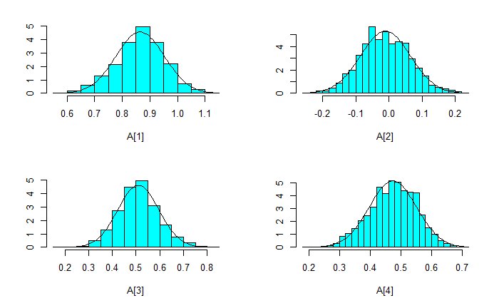

```r
library(MASS)
par(mfrow = c(2, 2))
for (j in 1:dim(Z)[2]) {
  truehist(Z[, j], xlab=paste("A[",j,"]",sep=""))
  curve(dnorm(x,mean=mean(Z[, j]),sd=sd(Z[, j])),add=T)
}
```